# Odds Ratios: Predictors & ASP Scales

- Show All Code
- Hide All Code
- View Source

# Overview

This is the second page of the Dissertation Study 1 workflow. The Profiles page established a four-class latent profile solution capturing distinct combinations of positive and negative adolescent risk-taking. This page asks the next question: **which demographic, peer, and parenting characteristics distinguish membership in those profiles?**

Posterior-probability-weighted multinomial logistic regression was estimated using the BCH three-step method so predictor associations account for classification uncertainty in the latent profiles (Bolck, Croon, and Hagenaars 2004). Continuous predictors were standardized before analysis.

The inferential workflow proceeds in three steps:

Models are shown with both **C1 (High PR–Low NR)** and **C3 (Low PR–High NR)** as reference classes so comparisons can be interpreted from both the low-negative-risk and high-negative-risk sides of the profile solution.

**Analysis Workflow**

**1. Profiles** → **2. Odds Ratios** → **3. Interaction & Comparisons**

Profiles · Odds Ratios · Interaction & Comparisons

The next page, Interaction & Comparisons, tests whether the autonomy-supportive parenting association varies by adolescent sex or age and places BH-corrected profile comparisons side by side.

```r
# Shared by every OR section below to clean data import
tidy_params <- function(raw, cluster_cols) {
  raw %>%
    rename_with(~ "predictor_var", 1) %>%
    rename(omnibus_p = `p-value`) %>%
    pivot_longer(
      cols      = all_of(cluster_cols),
      names_to  = "cluster_raw",
      values_to = "log_odds") %>%
    mutate(
      predictor_label = recode(predictor_var, !!!pred_labels),
      log_odds        = as.numeric(log_odds),
      cluster         = recode(cluster_raw,
                          "Cluster1" = "C1", "Cluster2" = "C2",
                          "Cluster3" = "C3", "Cluster4" = "C4"),
      cluster         = factor(cluster, levels = c("C1", "C2", "C3", "C4")),
      OR              = exp(log_odds)) %>%
    select(predictor_label, predictor_var, cluster, log_odds, OR, omnibus_p)
}
```

# Data Import and Cleaning

Odds-ratio parameters and paired comparisons for each predictor, referenced against Class 1 and Class 3 respectively, are read in from the project’s Excel results workbook. Import code is included but not rendered below.

**Data Import of C1 as Reference**

```r
# View first rows of c1 reference as data import example
gt(c1_params_raw) |> tab_header(title = "c1 as reference parameters")
```

c1 as reference parameters

| Covariates | Cluster1 | Cluster2 | Cluster3 | Cluster4 | Wald | p-value |
| --- | --- | --- | --- | --- | --- | --- |
| female | 0 | -1.1397 | -1.1762 | -0.0246 | 252.9603 | 1.5e-54 |
| Zwave1age | 0 | 0.0978 | 0.4479 | 0.3739 | 81.5690 | 1.4e-17 |
| Zpeer_subuse | 0 | 0.4471 | 1.6031 | 1.2788 | 729.6575 | 7.8e-158 |
| pub_timing | 0 | -0.1350 | 0.1515 | 0.1929 | 52.3557 | 2.5e-11 |
| Zasp | 0 | -0.1339 | -0.4030 | -0.2974 | 59.0078 | 9.6e-13 |

**Data Import of Paired Comparisons Between Classes (clusters)**

```r
# View last rows of paired comparisons as data import example
gt(c1_pairs_raw) |>
  tab_header(title = "predictors paired comparisons") |>
  cols_label(
    cluster_a = "Class",
    cluster_b = "Class" )
```

predictors paired comparisons

| covariate | Class | Class | Wald | df | p-value |
| --- | --- | --- | --- | --- | --- |
| Intercept | 1 | 2 | 113.8264 | 1 | 1.4e-26 |
| Intercept | 1 | 3 | 46.6882 | 1 | 8.3e-12 |
| Intercept | 1 | 4 | 95.3149 | 1 | 1.6e-22 |
| Intercept | 2 | 3 | 288.9438 | 1 | 8.4e-65 |
| Intercept | 2 | 4 | 386.3619 | 1 | 5.1e-86 |
| Intercept | 3 | 4 | 8.6115 | 1 | 3.3e-03 |
| bio_sexD | 1 | 2 | 175.5118 | 1 | 4.6e-40 |
| bio_sexD | 1 | 3 | 96.0819 | 1 | 1.1e-22 |
| bio_sexD | 1 | 4 | 0.0514 | 1 | 8.2e-01 |
| bio_sexD | 2 | 3 | 0.0994 | 1 | 7.5e-01 |
| bio_sexD | 2 | 4 | 110.5552 | 1 | 7.4e-26 |
| bio_sexD | 3 | 4 | 80.3489 | 1 | 3.1e-19 |
| Zwave1age | 1 | 2 | 4.7768 | 1 | 2.9e-02 |
| Zwave1age | 1 | 3 | 51.8543 | 1 | 6.0e-13 |
| Zwave1age | 1 | 4 | 48.1391 | 1 | 4.0e-12 |
| Zwave1age | 2 | 3 | 34.5223 | 1 | 4.2e-09 |
| Zwave1age | 2 | 4 | 26.0805 | 1 | 3.3e-07 |
| Zwave1age | 3 | 4 | 1.2073 | 1 | 2.7e-01 |
| Zpeer_subuse | 1 | 2 | 47.9487 | 1 | 4.4e-12 |
| Zpeer_subuse | 1 | 3 | 511.9225 | 1 | 2.4e-113 |
| Zpeer_subuse | 1 | 4 | 397.8266 | 1 | 1.6e-88 |
| Zpeer_subuse | 2 | 3 | 375.2094 | 1 | 1.4e-83 |
| Zpeer_subuse | 2 | 4 | 223.9825 | 1 | 1.2e-50 |
| Zpeer_subuse | 3 | 4 | 30.7176 | 1 | 3.0e-08 |
| pub_timing | 1 | 2 | 9.7248 | 1 | 1.8e-03 |
| pub_timing | 1 | 3 | 6.8767 | 1 | 8.8e-03 |
| pub_timing | 1 | 4 | 12.5589 | 1 | 3.9e-04 |
| pub_timing | 2 | 3 | 28.4378 | 1 | 9.7e-08 |
| pub_timing | 2 | 4 | 39.0790 | 1 | 4.1e-10 |
| pub_timing | 3 | 4 | 0.4318 | 1 | 5.1e-01 |
| Zasp | 1 | 2 | 7.9154 | 1 | 4.9e-03 |
| Zasp | 1 | 3 | 51.0767 | 1 | 8.9e-13 |
| Zasp | 1 | 4 | 30.6871 | 1 | 3.0e-08 |
| Zasp | 2 | 3 | 28.2078 | 1 | 1.1e-07 |
| Zasp | 2 | 4 | 10.5232 | 1 | 1.2e-03 |
| Zasp | 3 | 4 | 3.9439 | 1 | 4.7e-02 |

**Clean Data Import**

```r
# ── Define Predictor Labels ───────────────────────────────────────────────────────
pred_labels <- c(
  "female"       = "Sex (Male = 0)",
  "bio_sexD"     = "Sex (Male = 0)",
  "Zwave1age"    = "Age",
  "Zpeer_subuse" = "Peer Substance Use",
  "pub_timing"   = "Pubertal Timing",
  "Zasp"         = "ASP")

# ── Reshape Reference-Class Parameters ────────────────────────────────────────────
c1_params <- tidy_params(c1_params_raw, c("Cluster1", "Cluster2", "Cluster3", "Cluster4"))
c3_params <- tidy_params(c3_params_raw, c("Cluster3", "Cluster4", "Cluster1", "Cluster2"))
```

## BH Correction on Pairwise Comparisons

**Cleaned Data with C1 as Reference**

```r
# Hide predictor_var (raw code) from the preview, keep predictor_label
gt(c1_params %>% select(-predictor_var)) |>
  tab_header(title = "data after custom function to clean output")
```

data after custom function to clean output

| predictor_label | cluster | log_odds | OR | omnibus_p |
| --- | --- | --- | --- | --- |
| Sex (Male = 0) | C1 | 0.0000 | 1.0000000 | 1.5e-54 |
| Sex (Male = 0) | C2 | -1.1397 | 0.3199150 | 1.5e-54 |
| Sex (Male = 0) | C3 | -1.1762 | 0.3084486 | 1.5e-54 |
| Sex (Male = 0) | C4 | -0.0246 | 0.9757001 | 1.5e-54 |
| Age | C1 | 0.0000 | 1.0000000 | 1.4e-17 |
| Age | C2 | 0.0978 | 1.1027422 | 1.4e-17 |
| Age | C3 | 0.4479 | 1.5650222 | 1.4e-17 |
| Age | C4 | 0.3739 | 1.4533918 | 1.4e-17 |
| Peer Substance Use | C1 | 0.0000 | 1.0000000 | 7.8e-158 |
| Peer Substance Use | C2 | 0.4471 | 1.5637707 | 7.8e-158 |
| Peer Substance Use | C3 | 1.6031 | 4.9684106 | 7.8e-158 |
| Peer Substance Use | C4 | 1.2788 | 3.5923263 | 7.8e-158 |
| Pubertal Timing | C1 | 0.0000 | 1.0000000 | 2.5e-11 |
| Pubertal Timing | C2 | -0.1350 | 0.8737159 | 2.5e-11 |
| Pubertal Timing | C3 | 0.1515 | 1.1635783 | 2.5e-11 |
| Pubertal Timing | C4 | 0.1929 | 1.2127615 | 2.5e-11 |
| ASP | C1 | 0.0000 | 1.0000000 | 9.6e-13 |
| ASP | C2 | -0.1339 | 0.8746775 | 9.6e-13 |
| ASP | C3 | -0.4030 | 0.6683121 | 9.6e-13 |
| ASP | C4 | -0.2974 | 0.7427469 | 9.6e-13 |

**Cleaned Data of Paired Comparisons Between Classes**

```r
# Show predictor_label instead of the raw "predictor" code
gt(c1_pairs %>% select(predictor_label, everything(), -predictor)) |>
  tab_header(title = "data after custom function to clean output") |>
  cols_label(
    predictor_label = "Predictor",
    cluster_a = "Class",
    cluster_b = "Class" )
```

data after custom function to clean output

| Predictor | Class | Class | Wald | df | p_value | p_adj | sig |
| --- | --- | --- | --- | --- | --- | --- | --- |
| Sex (Male = 0) | 1 | 2 | 175.5118 | 1 | 4.6e-40 | 2.760000e-39 | TRUE |
| Sex (Male = 0) | 1 | 3 | 96.0819 | 1 | 1.1e-22 | 4.714286e-22 | TRUE |
| Sex (Male = 0) | 1 | 4 | 0.0514 | 1 | 8.2e-01 | 8.200000e-01 | FALSE |
| Sex (Male = 0) | 2 | 3 | 0.0994 | 1 | 7.5e-01 | 7.758621e-01 | FALSE |
| Sex (Male = 0) | 2 | 4 | 110.5552 | 1 | 7.4e-26 | 3.700000e-25 | TRUE |
| Sex (Male = 0) | 3 | 4 | 80.3489 | 1 | 3.1e-19 | 1.162500e-18 | TRUE |
| Age | 1 | 2 | 4.7768 | 1 | 2.9e-02 | 3.480000e-02 | TRUE |
| Age | 1 | 3 | 51.8543 | 1 | 6.0e-13 | 2.000000e-12 | TRUE |
| Age | 1 | 4 | 48.1391 | 1 | 4.0e-12 | 1.090909e-11 | TRUE |
| Age | 2 | 3 | 34.5223 | 1 | 4.2e-09 | 9.000000e-09 | TRUE |
| Age | 2 | 4 | 26.0805 | 1 | 3.3e-07 | 5.210526e-07 | TRUE |
| Age | 3 | 4 | 1.2073 | 1 | 2.7e-01 | 3.000000e-01 | FALSE |
| Peer Substance Use | 1 | 2 | 47.9487 | 1 | 4.4e-12 | 1.100000e-11 | TRUE |
| Peer Substance Use | 1 | 3 | 511.9225 | 1 | 2.4e-113 | 7.200000e-112 | TRUE |
| Peer Substance Use | 1 | 4 | 397.8266 | 1 | 1.6e-88 | 2.400000e-87 | TRUE |
| Peer Substance Use | 2 | 3 | 375.2094 | 1 | 1.4e-83 | 1.400000e-82 | TRUE |
| Peer Substance Use | 2 | 4 | 223.9825 | 1 | 1.2e-50 | 9.000000e-50 | TRUE |
| Peer Substance Use | 3 | 4 | 30.7176 | 1 | 3.0e-08 | 5.625000e-08 | TRUE |
| Pubertal Timing | 1 | 2 | 9.7248 | 1 | 1.8e-03 | 2.454545e-03 | TRUE |
| Pubertal Timing | 1 | 3 | 6.8767 | 1 | 8.8e-03 | 1.100000e-02 | TRUE |
| Pubertal Timing | 1 | 4 | 12.5589 | 1 | 3.9e-04 | 5.850000e-04 | TRUE |
| Pubertal Timing | 2 | 3 | 28.4378 | 1 | 9.7e-08 | 1.711765e-07 | TRUE |
| Pubertal Timing | 2 | 4 | 39.0790 | 1 | 4.1e-10 | 9.461538e-10 | TRUE |
| Pubertal Timing | 3 | 4 | 0.4318 | 1 | 5.1e-01 | 5.464286e-01 | FALSE |
| ASP | 1 | 2 | 7.9154 | 1 | 4.9e-03 | 6.391304e-03 | TRUE |
| ASP | 1 | 3 | 51.0767 | 1 | 8.9e-13 | 2.670000e-12 | TRUE |
| ASP | 1 | 4 | 30.6871 | 1 | 3.0e-08 | 5.625000e-08 | TRUE |
| ASP | 2 | 3 | 28.2078 | 1 | 1.1e-07 | 1.833333e-07 | TRUE |
| ASP | 2 | 4 | 10.5232 | 1 | 1.2e-03 | 1.714286e-03 | TRUE |
| ASP | 3 | 4 | 3.9439 | 1 | 4.7e-02 | 5.423077e-02 | FALSE |

# Odds Ratios

Odds ratios test whether each predictor distinguishes class membership, computed twice: once with C1 (High PR-Low NR) as the reference class, once with C3 (Low PR-High NR), so both alcohol-problem-status groupings can anchor the comparison.

**OR Interpretation**

An OR above 1 means higher odds of membership in the comparison class relative to the reference, for a one-unit (or one-SD, for standardized predictors) increase in that predictor.

## Autonomy-Supportive Parenting

**C1 graph code**

```r
# ── Select Predictor and Significant Comparisons ──────────────────────────────────
c1_asp <- c1_params %>% filter(predictor_var == "Zasp")

# ── Identify Reference-Class Differences ──────────────────────────────────────────
ref_sig <- c1_pairs %>%
  filter(predictor == "Zasp",
         cluster_a == 1 | cluster_b == 1,
         sig == TRUE) %>%
  mutate(other = ifelse(cluster_a == 1, cluster_b, cluster_a)) %>%
  pull(other)

# ── Identify Additional Pairwise Differences ──────────────────────────────────────
other_sig <- c1_pairs %>%
  filter(predictor == "Zasp",
         cluster_a != 1, cluster_b != 1,
         sig == TRUE) %>%
  mutate(pair = paste0("C", cluster_a, " vs. C", cluster_b)) %>%
  pull(pair)

# ── Prepare Plot Annotations ──────────────────────────────────────────────────────
c1_asp <- c1_asp %>%
  mutate(
    ast_label = ifelse(as.integer(cluster) %in% ref_sig, "*", ""),
    ast_y     = OR + max(OR) * ast_nudge_pct)

# ── Define Plot Labels ────────────────────────────────────────────────────────────
plot_title  <- "* Significantly different than C1"
x_label     <- "Reference: C1"
y_label     <- y_lab
fig_caption <- if (length(other_sig) > 0) {
                 paste0("Additional significant pairwise differences after BH correction (FDR < .05): ",
                        paste(other_sig, collapse = "; "), ".")
              } else {
                 "No additional pairwise differences were significant after BH correction."
}

# ── Build Odds-Ratio Figure ───────────────────────────────────────────────────────
p_c1_asp <- ggplot(c1_asp, aes(x = cluster, y = OR, fill = cluster)) +
  geom_col(width = bar_width, alpha = bar_alpha,
           linewidth = bar_outline_lwd) +
  geom_hline(yintercept = 1, color = "gray20",
             linewidth = ref_line_lwd, linetype = ref_line_type) +
  geom_text(aes(y = OR, label = round(OR, 2)),
            color = or_label_color, size = or_label_size, vjust = or_label_vjust) +
  geom_text(aes(y = ast_y, label = ast_label),
            size = ast_text_size, vjust = 0.5) +
  scale_fill_manual(values = cluster_colors) +
  scale_y_continuous(expand = expansion(mult = c(0, 0.18)),
                     labels = number_format(accuracy = 0.1)) +
  labs(title = plot_title, x = x_label, y = y_label,
       caption = str_wrap(fig_caption, width = 60)) +
  or_theme +
  theme( legend.position    = "none",
    axis.title.y = element_blank(),
    axis.title.x = element_blank())
```

**C3 graph code**

```r
# ── Select Predictor and Significant Comparisons ──────────────────────────────────
c3_asp <- c3_params %>% filter(predictor_var == "Zasp")

# ── Identify Reference-Class Differences ──────────────────────────────────────────
ref_sig <- c3_pairs %>%
  filter(predictor == "Zasp",
         cluster_a == 3 | cluster_b == 3,
         sig == TRUE) %>%
  mutate(other = ifelse(cluster_a == 3, cluster_b, cluster_a)) %>%
  pull(other)

# ── Identify Additional Pairwise Differences ──────────────────────────────────────
other_sig <- c3_pairs %>%
  filter(predictor == "Zasp",
         cluster_a != 3, cluster_b != 3,
         sig == TRUE) %>%
  mutate(pair = paste0("C", cluster_a, " vs. C", cluster_b)) %>%
  pull(pair)

# ── Prepare Plot Annotations ──────────────────────────────────────────────────────
c3_asp <- c3_asp %>%
  mutate(
    ast_label = ifelse(as.integer(cluster) %in% ref_sig, "*", ""),
    ast_y     = OR + max(OR) * ast_nudge_pct)

# ── Define Plot Labels ────────────────────────────────────────────────────────────
plot_title  <- "* Significantly different than C3"
x_label     <- "Reference: C3"
y_label     <- y_lab
fig_caption <- if (length(other_sig) > 0) {
                 paste0("Additional significant pairwise differences after BH correction (FDR < .05): ",
                        paste(other_sig, collapse = "; "), ".")
               } else {
                 "No additional pairwise differences were significant after BH correction."
 }

# ── Build Odds-Ratio Figure ───────────────────────────────────────────────────────
p_c3_asp <- ggplot(c3_asp, aes(x = cluster, y = OR, fill = cluster)) +
  geom_col(width = bar_width, alpha = bar_alpha,
           linewidth = bar_outline_lwd) +
  geom_hline(yintercept = 1, color = "gray20",
             linewidth = ref_line_lwd, linetype = ref_line_type) +
  geom_text(aes(y = OR, label = round(OR, 2)),
            color = or_label_color, size = or_label_size, vjust = or_label_vjust) +
  geom_text(aes(y = ast_y, label = ast_label),
            size = ast_text_size, vjust = 0.5) +
  scale_fill_manual(values = cluster_colors) +
  scale_y_continuous(expand = expansion(mult = c(0, 0.18)),
                     labels = number_format(accuracy = 0.1)) +
  labs(title = plot_title, x = x_label, y = y_label,
       caption = str_wrap(fig_caption, width = 60)) +
  or_theme +
  theme( legend.position    = "none",
    axis.title.y = element_blank(),
    axis.title.x = element_blank())
```

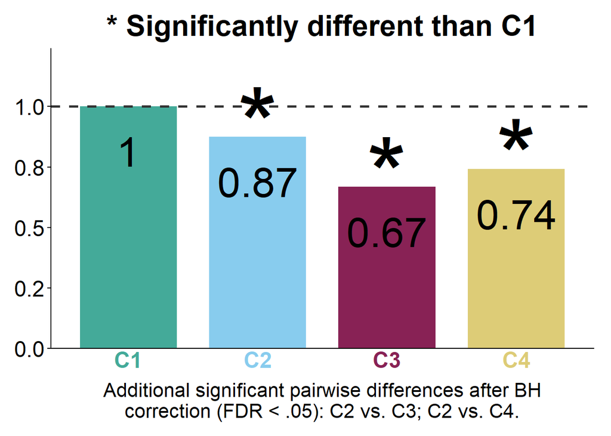

Figure 1

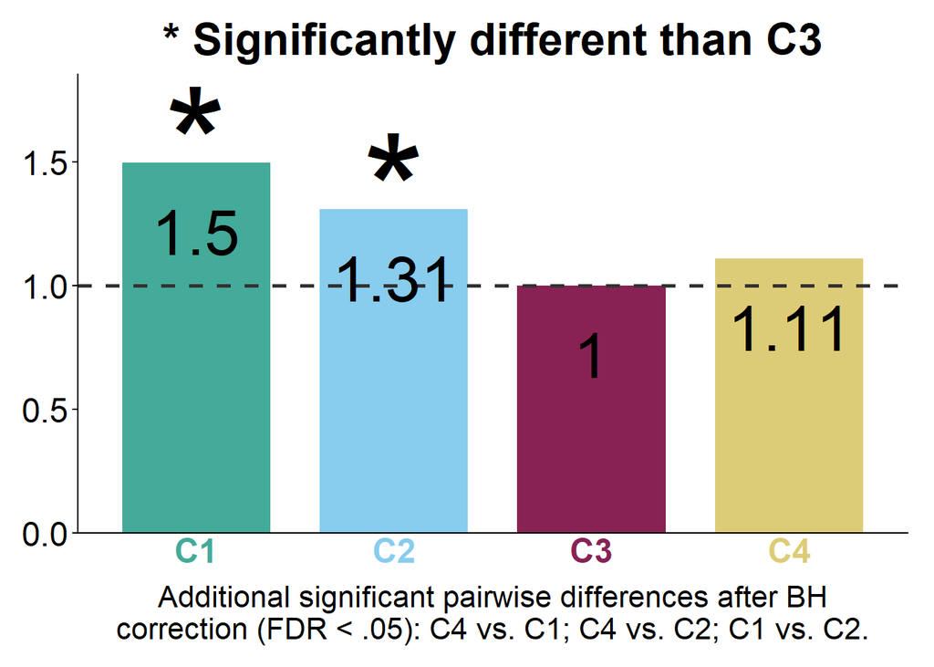

Figure 2

## Biological Sex

**C1 graph code**

```r
# ── Select Predictor and Significant Comparisons ──────────────────────────────────
c1_sex <- c1_params %>% filter(predictor_var == "female")

# ── Identify Reference-Class Differences ──────────────────────────────────────────
ref_sig <- c1_pairs %>%
  filter(predictor == "bio_sexD",
         cluster_a == 1 | cluster_b == 1,
         sig == TRUE) %>%
  mutate(other = ifelse(cluster_a == 1, cluster_b, cluster_a)) %>%
  pull(other)  # Cluster numbers sig different from C1

# ── Identify Additional Pairwise Differences ──────────────────────────────────────
other_sig <- c1_pairs %>%
  filter(predictor == "bio_sexD",
         cluster_a != 1, cluster_b != 1,
         sig == TRUE) %>%
  mutate(pair = paste0("C", cluster_a, " vs. C", cluster_b)) %>%
  pull(pair)  # Non-reference sig pairs for caption

# ── Prepare Plot Annotations ──────────────────────────────────────────────────────
c1_sex <- c1_sex %>%
  mutate(
    ast_label = ifelse(as.integer(cluster) %in% ref_sig, "*", ""),
    ast_y     = OR + max(OR) * ast_nudge_pct)

# ── Define Plot Labels ────────────────────────────────────────────────────────────
plot_title   <- "Sex (Female vs. Male)"
x_label      <- "Reference: C1"
y_label      <- "Odds Ratio - C1 as Reference"
fig_caption  <- if (length(other_sig) > 0) {
                  paste0("Additional significant pairwise differences after BH correction (FDR < .05): ",
                         paste(other_sig, collapse = "; "), ".")
              }  else {
                  "No additional pairwise differences were significant after BH correction."
 }

# ── Build Odds-Ratio Figure ───────────────────────────────────────────────────────
p_c1_sex <- ggplot(c1_sex, aes(x = cluster, y = OR, fill = cluster)) +
  geom_col(width = bar_width, alpha = bar_alpha,
           linewidth = bar_outline_lwd) +
  geom_hline(yintercept = 1, color = "gray20",
             linewidth = ref_line_lwd, linetype = ref_line_type) +
  geom_text(aes(y = OR, label = round(OR, 2)),
            color = or_label_color, size = or_label_size, vjust = or_label_vjust) +
  geom_text(aes(y = ast_y, label = ast_label),
            size = ast_text_size, vjust = 0.5) +
  scale_fill_manual(values = cluster_colors) +
  scale_y_continuous(expand = expansion(mult = c(0, 0.18)),
                     labels = number_format(accuracy = 0.1)) +
  labs(title = plot_title, x = x_label, y = y_label,
       caption = str_wrap(fig_caption, width = 60)) +
  or_theme +
  theme( legend.position    = "none",
    axis.title.y = element_blank(),
    axis.title.x = element_blank())
```

**C3 graph code**

```r
# ── Select Predictor and Significant Comparisons ──────────────────────────────────
c3_sex <- c3_params %>% filter(predictor_var == "female")

# ── Identify Reference-Class Differences ──────────────────────────────────────────
ref_sig <- c3_pairs %>%
  filter(predictor == "bio_sexD",
         cluster_a == 3 | cluster_b == 3,
         sig == TRUE) %>%
  mutate(other = ifelse(cluster_a == 3, cluster_b, cluster_a)) %>%
  pull(other)

# ── Identify Additional Pairwise Differences ──────────────────────────────────────
other_sig <- c3_pairs %>%
  filter(predictor == "bio_sexD",
         cluster_a != 3, cluster_b != 3,
         sig == TRUE) %>%
  mutate(pair = paste0("C", cluster_a, " vs. C", cluster_b)) %>%
  pull(pair)

# ── Prepare Plot Annotations ──────────────────────────────────────────────────────
c3_sex <- c3_sex %>%
  mutate(
    ast_label = ifelse(as.integer(cluster) %in% ref_sig, "*", ""),
    ast_y     = OR + max(OR) * ast_nudge_pct)

# ── Define Plot Labels ────────────────────────────────────────────────────────────
plot_title  <- "Sex (Female vs. Male)"
# X_label     <- "Reference: C3"
# Y_label     <- "Odds Ratio - C3 as Reference"
fig_caption <- if (length(other_sig) > 0) {
                 paste0("Additional significant pairwise differences after BH correction (FDR < .05): ",
                        paste(other_sig, collapse = "; "), ".")
               } else {
                 "No additional pairwise differences were significant after BH correction."
 }

# ── Build Odds-Ratio Figure ───────────────────────────────────────────────────────
p_c3_sex <- ggplot(c3_sex, aes(x = cluster, y = OR, fill = cluster)) +
  geom_col(width = bar_width, alpha = bar_alpha,
           linewidth = bar_outline_lwd) +
  geom_hline(yintercept = 1, color = "gray20",
             linewidth = ref_line_lwd, linetype = ref_line_type) +
  geom_text(aes(y = OR, label = round(OR, 2)),
            color = or_label_color, size = or_label_size, vjust = or_label_vjust) +
  geom_text(aes(y = ast_y, label = ast_label),
            size = ast_text_size, vjust = 0.5) +
  scale_fill_manual(values = cluster_colors) +
  scale_y_continuous(expand = expansion(mult = c(0, 0.18)),
                     labels = number_format(accuracy = 0.1)) +
  labs(title = plot_title, x = x_label, y = y_label,
       caption = str_wrap(fig_caption, width = 60)) +
  or_theme +
  theme( legend.position    = "none",
    axis.title.y = element_blank(),
    axis.title.x = element_blank())
```

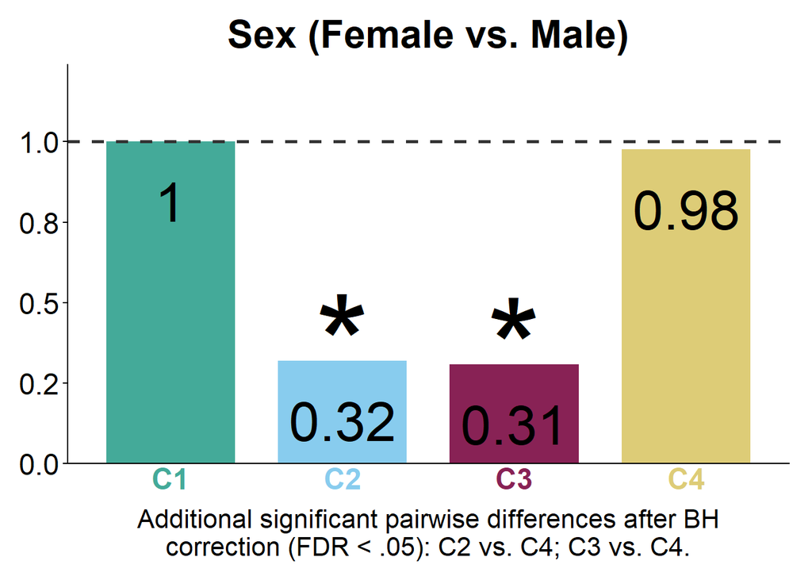

Figure 3

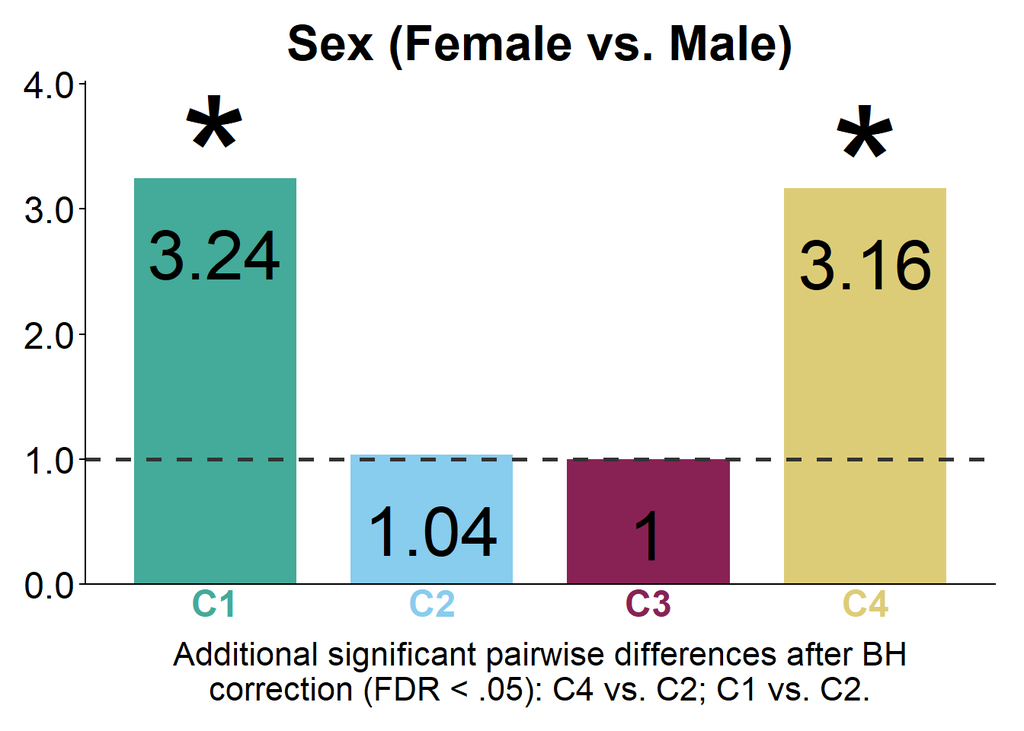

Figure 4

**Sex.** As the proportion of females in a profile increases, compared to C1 the odds of being in C2 or C3 significantly decrease; compared to C3, the odds of being in C1 or C4 increase (C2 vs. C4 and C3 vs. C4 also significant) — consistent with prior findings of higher male delinquency rates (Miller, Malone, and Dodge 2010).

## Child Age

**C1 graph code**

```r
# ── Select Predictor and Significant Comparisons ──────────────────────────────────
c1_age <- c1_params %>% filter(predictor_var == "Zwave1age")

# ── Identify Reference-Class Differences ──────────────────────────────────────────
ref_sig <- c1_pairs %>%
  filter(predictor == "Zwave1age",
         cluster_a == 1 | cluster_b == 1,
         sig == TRUE) %>%
  mutate(other = ifelse(cluster_a == 1, cluster_b, cluster_a)) %>%
  pull(other)

# ── Identify Additional Pairwise Differences ──────────────────────────────────────
other_sig <- c1_pairs %>%
  filter(predictor == "Zwave1age",
         cluster_a != 1, cluster_b != 1,
         sig == TRUE) %>%
  mutate(pair = paste0("C", cluster_a, " vs. C", cluster_b)) %>%
  pull(pair)

# ── Prepare Plot Annotations ──────────────────────────────────────────────────────
c1_age <- c1_age %>%
  mutate(
    ast_label = ifelse(as.integer(cluster) %in% ref_sig, "*", ""),
    ast_y     = OR + max(OR) * ast_nudge_pct)

# ── Define Plot Labels ────────────────────────────────────────────────────────────
plot_title  <- "Age"
x_label     <- "Reference: C1"
y_label     <- y_lab
fig_caption <- if (length(other_sig) > 0) {
                 paste0("Additional significant pairwise differences after BH correction (FDR < .05): ",
                        paste(other_sig, collapse = "; "), ".")
               } else {
                 "No additional pairwise differences were significant after BH correction."
               }

# ── Build Odds-Ratio Figure ───────────────────────────────────────────────────────
p_c1_age <- ggplot(c1_age, aes(x = cluster, y = OR, fill = cluster)) +
  geom_col(width = bar_width, alpha = bar_alpha,
           linewidth = bar_outline_lwd) +
  geom_hline(yintercept = 1, color = "gray20",
             linewidth = ref_line_lwd, linetype = ref_line_type) +
  geom_text(aes(y = OR, label = round(OR, 2)),
            color = or_label_color, size = or_label_size, vjust = or_label_vjust) +
  geom_text(aes(y = ast_y, label = ast_label),
            size = ast_text_size, vjust = 0.5) +
  scale_fill_manual(values = cluster_colors) +
  scale_y_continuous(expand = expansion(mult = c(0, 0.18)),
                     labels = number_format(accuracy = 0.1)) +
  labs(title = plot_title, x = x_label, y = y_label,
       caption = str_wrap(fig_caption, width = 60)) +
  or_theme +
  theme( legend.position    = "none",
    axis.title.y = element_blank(),
    axis.title.x = element_blank())
```

**C3 graph code**

```r
# ── Select Predictor and Significant Comparisons ──────────────────────────────────
c3_age <- c3_params %>% filter(predictor_var == "Zwave1age")

# ── Identify Reference-Class Differences ──────────────────────────────────────────
ref_sig <- c3_pairs %>%
  filter(predictor == "Zwave1age",
         cluster_a == 3 | cluster_b == 3,
         sig == TRUE) %>%
  mutate(other = ifelse(cluster_a == 3, cluster_b, cluster_a)) %>%
  pull(other)

# ── Identify Additional Pairwise Differences ──────────────────────────────────────
other_sig <- c3_pairs %>%
  filter(predictor == "Zwave1age",
         cluster_a != 3, cluster_b != 3,
         sig == TRUE) %>%
  mutate(pair = paste0("C", cluster_a, " vs. C", cluster_b)) %>%
  pull(pair)

# ── Prepare Plot Annotations ──────────────────────────────────────────────────────
c3_age <- c3_age %>%
  mutate(
    ast_label = ifelse(as.integer(cluster) %in% ref_sig, "*", ""),
    ast_y     = OR + max(OR) * ast_nudge_pct)

# ── Define Plot Labels ────────────────────────────────────────────────────────────
plot_title  <- "Age"
x_label     <- "Reference: C3"
y_label     <- y_lab
fig_caption <- if (length(other_sig) > 0) {
                 paste0("Additional significant pairwise differences after BH correction (FDR < .05): ",
                        paste(other_sig, collapse = "; "), ".")
               } else {
                 "No additional pairwise differences were significant after BH correction."
 }

# ── Build Odds-Ratio Figure ───────────────────────────────────────────────────────
p_c3_age<- ggplot(c3_age, aes(x = cluster, y = OR, fill = cluster)) +
  geom_col(width = bar_width, alpha = bar_alpha,
           linewidth = bar_outline_lwd) +
  geom_hline(yintercept = 1, color = "gray20",
             linewidth = ref_line_lwd, linetype = ref_line_type) +
  geom_text(aes(y = OR, label = round(OR, 2)),
            color = or_label_color, size = or_label_size, vjust = or_label_vjust) +
  geom_text(aes(y = ast_y, label = ast_label),
            size = ast_text_size, vjust = 0.5) +
  scale_fill_manual(values = cluster_colors) +
  scale_y_continuous(expand = expansion(mult = c(0, 0.18)),
                     labels = number_format(accuracy = 0.1)) +
  labs(title = plot_title, x = x_label, y = y_label,
       caption = str_wrap(fig_caption, width = 60)) +
  or_theme +
  theme( legend.position    = "none",
    axis.title.y = element_blank(),
    axis.title.x = element_blank())
```

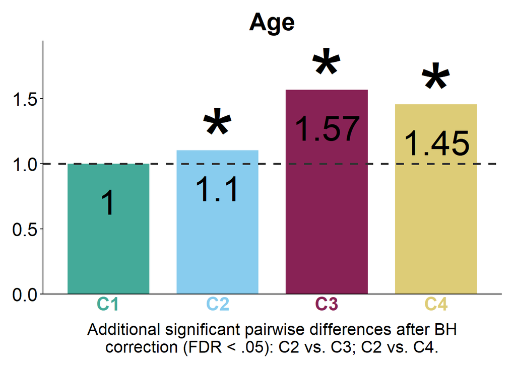

Figure 5

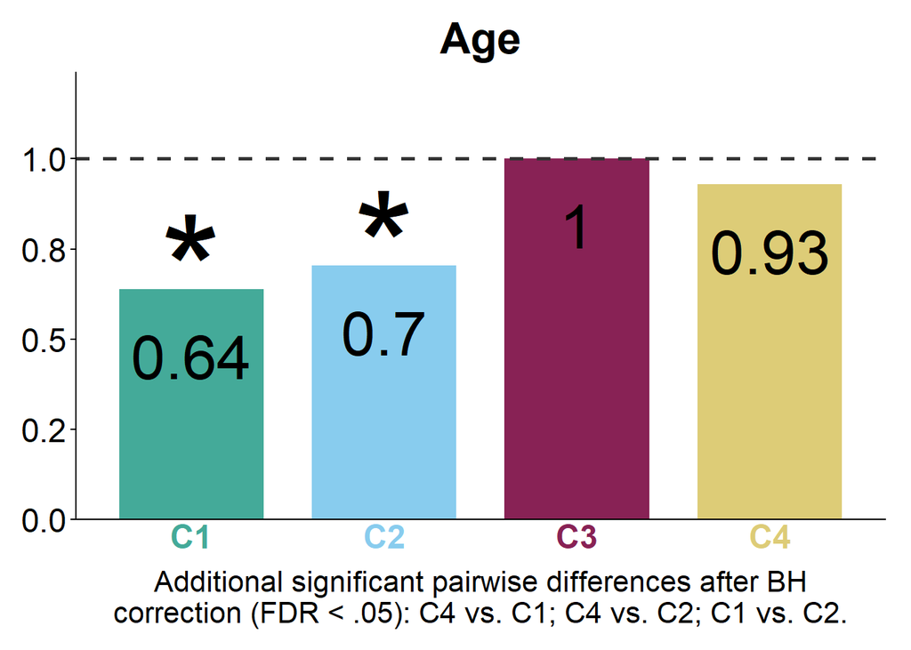

Figure 6

**Child Age.** As age increases, the odds of being in any profile compared to C1 increase significantly; compared to C3, the odds of being in either zero-alcohol-problem profile decrease (C2 vs. C3 and C2 vs. C4 also significant) — consistent with developmental increases in negative risk-taking across adolescence (Duell et al. 2018; Moffitt 2017).

## Peer Substance Use

**C1 graph code**

```r
# ── Select Predictor and Significant Comparisons ──────────────────────────────────
c1_peer <- c1_params %>% filter(predictor_var == "Zpeer_subuse")

# ── Identify Reference-Class Differences ──────────────────────────────────────────
ref_sig <- c1_pairs %>%
  filter(predictor == "Zpeer_subuse",
         cluster_a == 1 | cluster_b == 1,
         sig == TRUE) %>%
  mutate(other = ifelse(cluster_a == 1, cluster_b, cluster_a)) %>%
  pull(other)

# ── Identify Additional Pairwise Differences ──────────────────────────────────────
other_sig <- c1_pairs %>%
  filter(predictor == "Zpeer_subuse",
         cluster_a != 1, cluster_b != 1,
         sig == TRUE) %>%
  mutate(pair = paste0("C", cluster_a, " vs. C", cluster_b)) %>%
  pull(pair)

# ── Prepare Plot Annotations ──────────────────────────────────────────────────────
c1_peer <- c1_peer %>%
  mutate(
    ast_label = ifelse(as.integer(cluster) %in% ref_sig, "*", ""),
    ast_y     = OR + max(OR) * ast_nudge_pct)

# ── Define Plot Labels ────────────────────────────────────────────────────────────
plot_title  <- "Peer Substance Use"
x_label     <- "Reference: C1"
y_label     <- y_lab
fig_caption <- if (length(other_sig) > 0) {
                 paste0("Additional significant pairwise differences after BH correction (FDR < .05): ",
                        paste(other_sig, collapse = "; "), ".")
               } else {
                 "No additional pairwise differences were significant after BH correction."
 }

# ── Build Odds-Ratio Figure ───────────────────────────────────────────────────────
p_c1_peer <- ggplot(c1_peer, aes(x = cluster, y = OR, fill = cluster)) +
  geom_col(width = bar_width, alpha = bar_alpha,
           linewidth = bar_outline_lwd) +
  geom_hline(yintercept = 1, color = "gray20",
             linewidth = ref_line_lwd, linetype = ref_line_type) +
  geom_text(aes(y = OR, label = round(OR, 2)),
            color = or_label_color, size = or_label_size, vjust = or_label_vjust) +
  geom_text(aes(y = ast_y, label = ast_label),
            size = ast_text_size, vjust = 0.5) +
  scale_fill_manual(values = cluster_colors) +
  scale_y_continuous(expand = expansion(mult = c(0, 0.18)),
                     labels = number_format(accuracy = 0.1)) +
  labs(title = plot_title, x = x_label, y = y_label,
       caption = str_wrap(fig_caption, width = 60)) +
  or_theme +
  theme( legend.position    = "none",
    axis.title.y = element_blank(),
    axis.title.x = element_blank())
```

**C3 graph code**

```r
# ── Select Predictor and Significant Comparisons ──────────────────────────────────
c3_peer <- c3_params %>% filter(predictor_var == "Zpeer_subuse")

# ── Identify Reference-Class Differences ──────────────────────────────────────────
ref_sig <- c3_pairs %>%
  filter(predictor == "Zpeer_subuse",
         cluster_a == 3 | cluster_b == 3,
         sig == TRUE) %>%
  mutate(other = ifelse(cluster_a == 3, cluster_b, cluster_a)) %>%
  pull(other)

# ── Identify Additional Pairwise Differences ──────────────────────────────────────
other_sig <- c3_pairs %>%
  filter(predictor == "Zpeer_subuse",
         cluster_a != 3, cluster_b != 3,
         sig == TRUE) %>%
  mutate(pair = paste0("C", cluster_a, " vs. C", cluster_b)) %>%
  pull(pair)

# ── Prepare Plot Annotations ──────────────────────────────────────────────────────
c3_peer <- c3_peer %>%
  mutate(
    ast_label = ifelse(as.integer(cluster) %in% ref_sig, "*", ""),
    ast_y     = OR + max(OR) * ast_nudge_pct)

# ── Define Plot Labels ────────────────────────────────────────────────────────────
plot_title  <- "Peer Substance Use"
x_label     <- "Reference: C3"
y_label     <- y_lab
fig_caption <- if (length(other_sig) > 0) {
                 paste0("Additional significant pairwise differences after BH correction (FDR < .05): ",
                        paste(other_sig, collapse = "; "), ".")
               } else {
                 "No additional pairwise differences were significant after BH correction."
 }

# ── Build Odds-Ratio Figure ───────────────────────────────────────────────────────
p_c3_peer <- ggplot(c3_peer,aes(x = cluster, y = OR, fill = cluster)) +
  geom_col(width = bar_width, alpha = bar_alpha,
           linewidth = bar_outline_lwd) +
  geom_hline(yintercept = 1, color = "gray20",
             linewidth = ref_line_lwd, linetype = ref_line_type) +
  geom_text(aes(y = OR, label = round(OR, 2)),
            color = or_label_color, size = or_label_size, vjust = or_label_vjust) +
  geom_text(aes(y = ast_y, label = ast_label),
            size = ast_text_size, vjust = 0.5) +
  scale_fill_manual(values = cluster_colors) +
  scale_y_continuous(expand = expansion(mult = c(0, 0.18)),
                     labels = number_format(accuracy = 0.1)) +
  labs(title = plot_title, x = x_label, y = y_label,
       caption = str_wrap(fig_caption, width = 60)) +
  or_theme +
  theme( legend.position    = "none",
    axis.title.y = element_blank(),
    axis.title.x = element_blank())
```

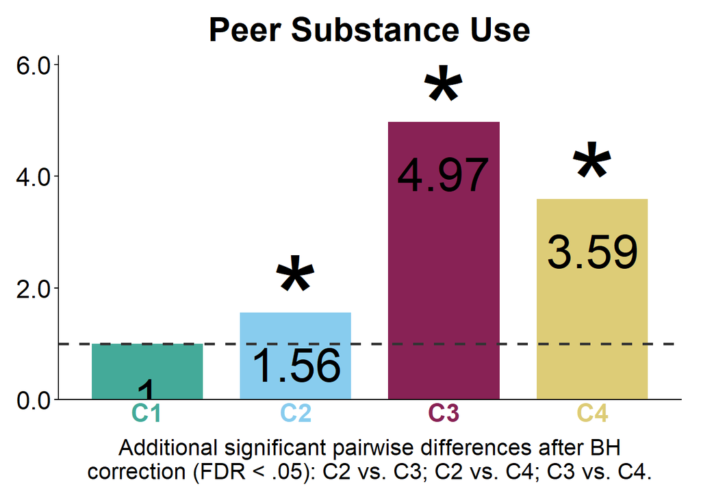

Figure 7

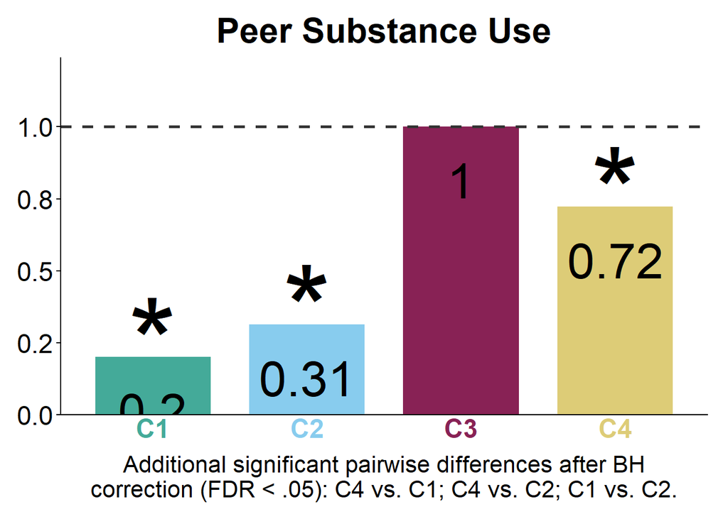

Figure 8

**Peer Substance Use.** As peer substance use increases, the odds of being in any profile compared to C1 increase significantly; compared to C3, the odds of being in either zero-alcohol-problem profile or C4 decrease (all six pairwise comparisons significant — the only predictor with every comparison reaching significance), matching literature identifying peer behavior as a robust proximal predictor of adolescent risk (Thomas J. Dishion, McCord, and Poulin 1999; Thomas J. Dishion and Tipsord 2011; Henneberger, Mushonga, and Preston 2021).

## Pubertal Timing

**C1 graph code**

```r
# ── Select Predictor and Significant Comparisons ──────────────────────────────────
c1_pub <- c1_params %>% filter(predictor_var == "pub_timing")

# ── Identify Reference-Class Differences ──────────────────────────────────────────
ref_sig <- c1_pairs %>%
  filter(predictor == "pub_timing",
         cluster_a == 1 | cluster_b == 1,
         sig == TRUE) %>%
  mutate(other = ifelse(cluster_a == 1, cluster_b, cluster_a)) %>%
  pull(other)

# ── Identify Additional Pairwise Differences ──────────────────────────────────────
other_sig <- c1_pairs %>%
  filter(predictor == "pub_timing",
         cluster_a != 1, cluster_b != 1,
         sig == TRUE) %>%
  mutate(pair = paste0("C", cluster_a, " vs. C", cluster_b)) %>%
  pull(pair)

# ── Prepare Plot Annotations ──────────────────────────────────────────────────────
c1_pub <- c1_pub %>%
  mutate(
    ast_label = ifelse(as.integer(cluster) %in% ref_sig, "*", ""),
    ast_y     = OR + max(OR) * ast_nudge_pct)

# ── Define Plot Labels ────────────────────────────────────────────────────────────
plot_title  <- "Pubertal Timing"
x_label     <- "Reference: C1"
y_label     <- y_lab
fig_caption <- if (length(other_sig) > 0) {
                 paste0("Additional significant pairwise differences after BH correction (FDR < .05): ",
                        paste(other_sig, collapse = "; "), ".")
             } else {
                 "No additional pairwise differences were significant after BH correction."
}

# ── Build Odds-Ratio Figure ───────────────────────────────────────────────────────
p_c1_pub <- ggplot(c1_pub, aes(x = cluster, y = OR, fill = cluster)) +
  geom_col(width = bar_width, alpha = bar_alpha,
           linewidth = bar_outline_lwd) +
  geom_hline(yintercept = 1, color = "gray20",
             linewidth = ref_line_lwd, linetype = ref_line_type) +
  geom_text(aes(y = OR, label = round(OR, 2)),
            color = or_label_color, size = or_label_size, vjust = or_label_vjust) +
  geom_text(aes(y = ast_y, label = ast_label),
            size = ast_text_size, vjust = 0.5) +
  scale_fill_manual(values = cluster_colors) +
  scale_y_continuous(expand = expansion(mult = c(0, 0.18)),
                     labels = number_format(accuracy = 0.1)) +
  labs(title = plot_title, x = x_label, y = y_label,
       caption = str_wrap(fig_caption, width = 60)) +
  or_theme +
  theme( legend.position    = "none",
    axis.title.y = element_blank(),
    axis.title.x = element_blank())
```

**C3 graph code**

```r
# ── Select Predictor and Significant Comparisons ──────────────────────────────────
c3_pub <- c3_params %>% filter(predictor_var == "pub_timing")

# ── Identify Reference-Class Differences ──────────────────────────────────────────
ref_sig <- c3_pairs %>%
  filter(predictor == "pub_timing",
         cluster_a == 3 | cluster_b == 3,
         sig == TRUE) %>%
  mutate(other = ifelse(cluster_a == 3, cluster_b, cluster_a)) %>%
  pull(other)

# ── Identify Additional Pairwise Differences ──────────────────────────────────────
other_sig <- c3_pairs %>%
  filter(predictor == "pub_timing",
         cluster_a != 3, cluster_b != 3,
         sig == TRUE) %>%
  mutate(pair = paste0("C", cluster_a, " vs. C", cluster_b)) %>%
  pull(pair)

# ── Prepare Plot Annotations ──────────────────────────────────────────────────────
c3_pub <- c3_pub %>%
  mutate(
    ast_label = ifelse(as.integer(cluster) %in% ref_sig, "*", ""),
    ast_y     = OR + max(OR) * ast_nudge_pct)

# ── Define Plot Labels ────────────────────────────────────────────────────────────
plot_title  <- "Pubertal Timing"
x_label     <- "Reference: C3"
y_label     <- y_lab
fig_caption <- if (length(other_sig) > 0) {
                 paste0("Additional significant pairwise differences after BH correction (FDR < .05): ",
                        paste(other_sig, collapse = "; "), ".")
               } else {
                 "No additional pairwise differences were significant after BH correction."
 }

# ── Build Odds-Ratio Figure ───────────────────────────────────────────────────────
p_c3_pub <- ggplot(c3_pub, aes(x = cluster, y = OR, fill = cluster)) +
  geom_col(width = bar_width, alpha = bar_alpha,
           linewidth = bar_outline_lwd) +
  geom_hline(yintercept = 1, color = "gray20",
             linewidth = ref_line_lwd, linetype = ref_line_type) +
  geom_text(aes(y = OR, label = round(OR, 2)),
            color = or_label_color, size = or_label_size, vjust = or_label_vjust) +
  geom_text(aes(y = ast_y, label = ast_label),
            size = ast_text_size, vjust = 0.5) +
  scale_fill_manual(values = cluster_colors) +
  scale_y_continuous(expand = expansion(mult = c(0, 0.18)),
                     labels = number_format(accuracy = 0.1)) +
  labs(title = plot_title, x = x_label, y = y_label,
       caption = str_wrap(fig_caption, width = 60)) +
  or_theme +
  theme( legend.position    = "none",
    axis.title.y = element_blank(),
    axis.title.x = element_blank())
```

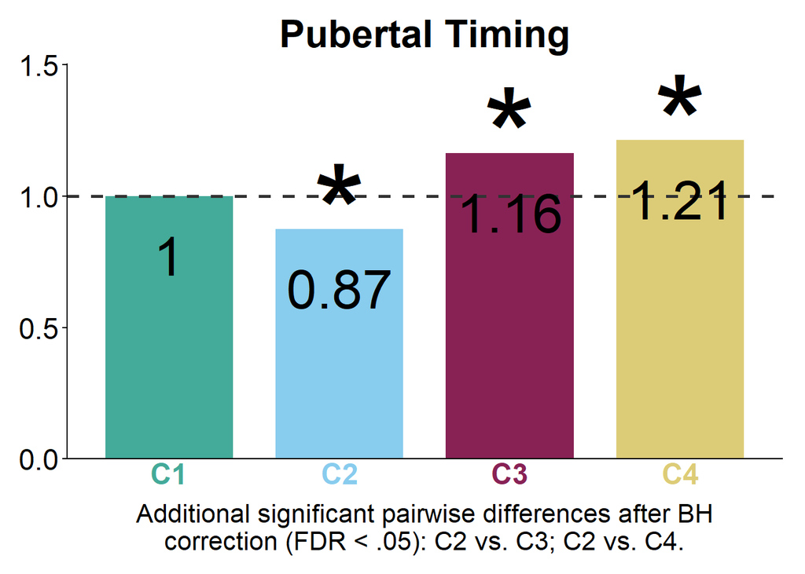

Figure 9

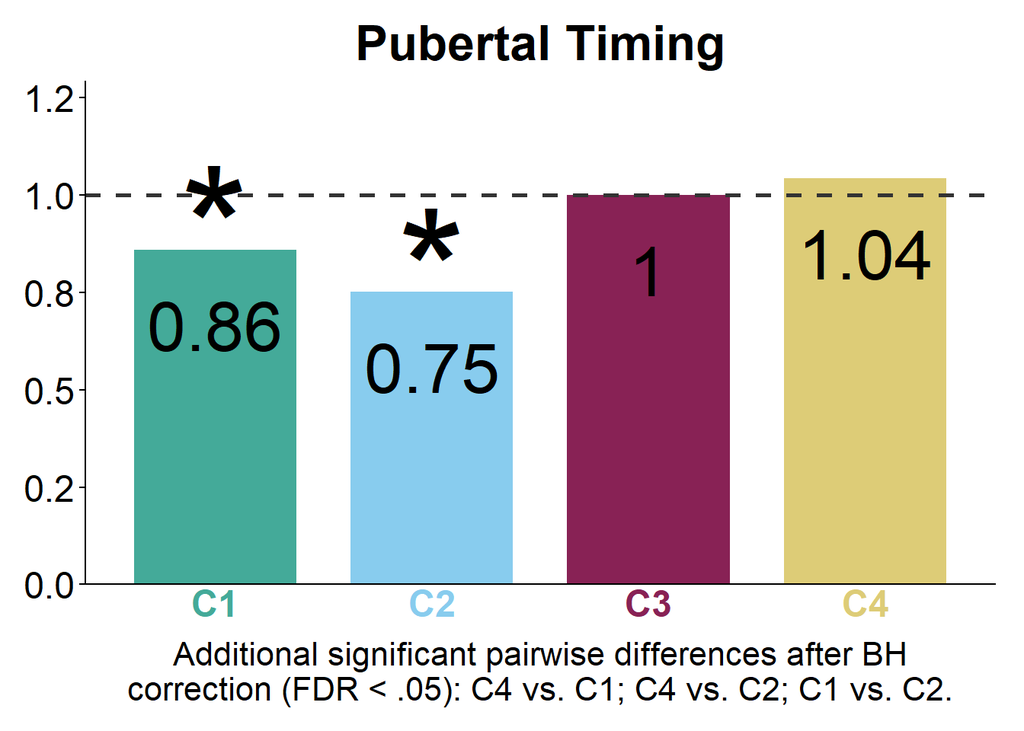

Figure 10

**Pubertal Timing.** As pubertal timing gets earlier, the odds of being in C2 decrease compared to C1, while the odds of being in either alcohol-problem profile increase compared to C1; compared to C3, the odds of being in either zero-alcohol-problem profile decrease (C2 vs. C3 and C2 vs. C4 also significant) — reinforcing that biological maturation shapes risk propensity above and beyond chronological age (Natsuaki, Biehl, and Ge 2009).

# Odds Ratios - Lines

The following chunks of code create the foundation for the odd ratio line graphs, or you can skip to the figures directly: Section 4.1.

**Significance Color Settings**

```r
# Colors for OR data points
color_sig_positive <- "#228833"  # Green  — OR > 1, sig vs. reference
color_sig_negative <- "#EE6677"  # Purple — OR < 1, sig vs. reference
color_nonsig       <- "#BBBBBB"  # Grey   — not sig vs. reference
color_reference    <- "black"  # Black  — reference cluster (OR = 1.0 by definition)

# Reference line at OR = 1.0
or_refline_color <- "grey20"
or_refline_type  <- "dashed"

# Point shape (size and line width set in appearance-settings below)
or_point_shape <- 21  # Filled circle with border
```

**Figure Appearance Settings**

```r
# Axis labels
ylab_or_c1 <- "Odds Ratio (vs. C1)"
ylab_or_c3 <- "Odds Ratio (vs. C3)"
xlab_or_C1 <- "Reference: C1"
xlab_or_C3 <- "Reference: C3"

# Font and text sizes — inherited from _setup.R:
# Plot_font, title_size, axis_title_size, axis_text_size, legend_text_size

# Point and line appearance — word-doc scale
or_point_shape <- 21  # Filled circle with border
or_point_size  <- 6
or_line_size   <- 3

# Legend color lookup (used by both line and bar figures)
or_legend_colors <- c(
  "Higher odds (sig.)"   = color_sig_positive,
  "Lower odds (sig.)"    = color_sig_negative,
  "Not significant"      = color_nonsig,
  "Reference (OR = 1.0)" = color_reference)

# Shared legend panel — appended to combined figures via patchwork
p_or_legend <- ggplot(
  data.frame(
    x     = 1:4,
    y     = 1,
    label = factor(names(or_legend_colors), levels = names(or_legend_colors))),
  aes(x = x, y = y, fill = label, color = label)) +
  geom_point(shape = or_point_shape, size = or_point_size + 1, stroke = 0.5) +
  scale_fill_manual(values  = or_legend_colors, name = NULL) +
  scale_color_manual(values = or_legend_colors, name = NULL) +
  guides(
    fill  = guide_legend(nrow = 1, keywidth = 0.6, keyheight = 0.6,
                         override.aes = list(shape = or_point_shape,
                                             size  = or_point_size)),
    color = "none") +
  coord_cartesian(ylim = c(100, 101)) +
  theme_void() +
  theme(
    legend.position = "bottom",
    legend.text     = element_text(size = legend_text_size, family = plot_font),
    plot.background = element_rect(fill = NA, color = NA))
```

**Build OR Data: Helper Function**

```r
# Build_or_long():
# Params     = output of tidy_params() for a given reference class
# Pairs      = output of apply_bh() for a given reference class
# Ref_cluster = "C1" or "C3" — the reference cluster label
# Ref_num    = 1 or 3 — the numeric cluster number used in pairs columns
# Returns a long data frame with one row per predictor × cluster,
# With columns: predictor_var, predictor_label, cluster, log_odds, OR, or_color
# The reference cluster row is added with OR = 1.0 and or_color = color_reference

build_or_long <- function(params, pairs, ref_cluster, ref_num) {

  # Map each predictor's tidy_params() name to its name in the pairs sheet
  pred_var_to_pairs_name <- c(
    "female"       = "bio_sexD",
    "Zwave1age"    = "Zwave1age",
    "Zpeer_subuse" = "Zpeer_subuse",
    "pub_timing"   = "pub_timing",
    "Zasp"        = "Zasp")

  # Non-reference clusters: flag significance vs. reference and assign color
  or_colored <- params %>%
    filter(cluster != ref_cluster) %>%
    rowwise() %>%
    mutate(
      pairs_pred = pred_var_to_pairs_name[predictor_var],
      is_sig = {
        hit <- pairs %>%
          filter(
            predictor == pairs_pred,
            (cluster_a == ref_num | cluster_b == ref_num),
            sig == TRUE) %>%
          mutate(other = ifelse(cluster_a == ref_num, cluster_b, cluster_a)) %>%
          filter(other == as.integer(gsub("C", "", as.character(cluster))))
        nrow(hit) > 0
      },
      or_color  = case_when(
        !is_sig             ~ color_nonsig,
        is_sig & OR > 1     ~ color_sig_positive,
        is_sig & OR < 1     ~ color_sig_negative,
        TRUE                ~ color_nonsig),
      sig_label = case_when(
        !is_sig             ~ "Not significant",
        is_sig & OR > 1     ~ "Higher odds (sig.)",
        is_sig & OR < 1     ~ "Lower odds (sig.)",
        TRUE                ~ "Not significant")) %>%
    ungroup() %>%
    select(predictor_var, predictor_label, cluster, log_odds, OR, or_color, sig_label)

  # Reference cluster row: OR = 1.0 by definition
  ref_rows <- params %>%
    filter(cluster == ref_cluster) %>%
    mutate(
      or_color  = color_reference,
      OR        = 1.0,
      log_odds  = 0,
      sig_label = "Reference (OR = 1.0)") %>%
    select(predictor_var, predictor_label, cluster, log_odds, OR, or_color, sig_label)

  # Combine and set factor levels for consistent ordering
  bind_rows(or_colored, ref_rows) %>%
    mutate(
      cluster   = factor(cluster, levels = c("C1", "C2", "C3", "C4")),
      sig_label = factor(sig_label, levels = names(or_legend_colors)))
}

# Build the long-format OR data for each reference class
c1_or_long <- build_or_long(c1_params, c1_pairs, ref_cluster = "C1", ref_num = 1)
c3_or_long <- build_or_long(c3_params, c3_pairs, ref_cluster = "C3", ref_num = 3)

# Predictor display order and titles (shared across all four predictor sections below)
pred_order  <- c("female", "Zwave1age", "Zpeer_subuse", "pub_timing")
pred_titles <- c(
  "female"       = "Sex (Male = 0)",
  "Zwave1age"    = "Age",
  "Zpeer_subuse" = "Peer Substance Use",
  "pub_timing"   = "Pubertal Timing",
  "Zasp"        = "Autonomy Supportive Parenting")

# X-axis cluster label colors to match cluster colors (same for C1 and C3 panels)
x_axis_colors_c1 <- cluster_colors[c("C1", "C2", "C3", "C4")]
x_axis_colors_c3 <- cluster_colors[c("C1", "C2", "C3", "C4")]
```

## Autonomy-Supportive Parenting

**C1 graph code**

```r
# ── Select Predictor and Significant Comparisons ──────────────────────────────────
pred_var   <- "Zasp"
pred_data  <- c1_or_long %>% filter(predictor_var == pred_var)
pred_title <- pred_titles[pred_var]

# This predictor's name in the pairs sheet
pairs_pred_name <- "Zasp"

# ── Identify Additional Pairwise Differences ──────────────────────────────────────
other_sig_c1 <- c1_pairs %>%
  filter(predictor == pairs_pred_name,
         cluster_a != 1, cluster_b != 1,
         sig == TRUE) %>%
  mutate(pair_label = paste0("C", cluster_a, " vs. C", cluster_b)) %>%
  pull(pair_label)

# Caption text summarizing those additional differences
fig_caption_c1 <- if (length(other_sig_c1) > 0) {
  paste0("Additional significant pairwise differences after BH correction (FDR < .05): ",
         paste(other_sig_c1, collapse = "; "), ".")
} else {
  "No additional pairwise differences were significant after BH correction."
}

# Build this predictor's panel
p_line_c1_asp <- ggplot(pred_data, aes(x = cluster, y = OR)) +
  geom_hline(yintercept = 1.0,
             linetype   = or_refline_type,
             color      = or_refline_color,
             linewidth  = 0.4) +
  geom_line(aes(group = 1),
            color     = "#BBBBBB",
            linewidth = or_line_size,
            linetype  = "solid") +
  geom_point(aes(fill = sig_label, color = sig_label),
             shape  = or_point_shape,
             size   = or_point_size,
             stroke = 0.5) +
  scale_fill_manual(values = or_legend_colors, name = NULL, drop = FALSE) +
  scale_color_manual(values = or_legend_colors, name = NULL, drop = FALSE) +
  scale_y_log10(
    labels = label_number(accuracy = 0.1),
    expand = expansion(mult = c(0.15, 0.15))) +
  labs(title = pred_title,
       caption = str_wrap(fig_caption_c1, width = 60)) +
  theme_classic(base_size = axis_text_size, base_family = plot_font) +
  theme(
    legend.position    = "none",
    plot.caption    = element_text(size = 14, hjust = .5, face = "plain",
                                   family = plot_font),
    plot.title         = element_text(size = axis_title_size, face = "plain",
                                      hjust = 0.5, family = plot_font),
    axis.title.y       = element_blank(),
    axis.title.x       = element_blank(),
    axis.text.x        = element_text(size = axis_text_size, face = "plain",
                                      family = plot_font, angle = 0,
                                      hjust = .5, vjust = 1,
                                      color = x_axis_colors_c1),
    axis.text.y        = element_text(size = axis_text_size, family = plot_font,
                                      face = "plain"),
    axis.ticks.x       = element_blank(),
    panel.grid.major.y = element_blank(),
    panel.grid.major.x = element_blank(),
    plot.background    = element_rect(fill = NA, color = NA),
    panel.background   = element_rect(fill = NA, color = NA))
```

**C3 graph code**

```r
# ── Select Predictor and Significant Comparisons ──────────────────────────────────
pred_var   <- "Zasp"
pred_data  <- c3_or_long %>% filter(predictor_var == pred_var)
pred_title <- pred_titles[pred_var]

# This predictor's name in the pairs sheet
pairs_pred_name <- "Zasp"

# ── Identify Additional Pairwise Differences ──────────────────────────────────────
other_sig_c3 <- c3_pairs %>%
  filter(predictor == pairs_pred_name,
         cluster_a != 3, cluster_b != 3,
         sig == TRUE) %>%
  mutate(pair_label = paste0("C", cluster_a, " vs. C", cluster_b)) %>%
  pull(pair_label)

# Caption text summarizing those additional differences
fig_caption_c3 <- if (length(other_sig_c3) > 0) {
  paste0("Additional significant pairwise differences after BH correction (FDR < .05): ",
         paste(other_sig_c3, collapse = "; "), ".")
} else {
  "No additional pairwise differences were significant after BH correction."
}

# Build this predictor's panel
p_line_c3_asp <- ggplot(pred_data, aes(x = cluster, y = OR)) +
  geom_hline(yintercept = 1.0,
             linetype   = or_refline_type,
             color      = or_refline_color,
             linewidth  = 0.4) +
  geom_line(aes(group = 1),
            color     = "grey65",
            linewidth = or_line_size,
            linetype  = "solid") +
  geom_point(aes(fill = sig_label, color = sig_label),
             shape  = or_point_shape,
             size   = or_point_size,
             stroke = 0.5) +
  scale_fill_manual(values = or_legend_colors, name = NULL, drop = FALSE) +
  scale_color_manual(values = or_legend_colors, name = NULL, drop = FALSE) +
  scale_y_log10(
    labels = label_number(accuracy = 0.1),
    expand = expansion(mult = c(0.15, 0.15))) +
  labs(title = pred_title,
       caption = str_wrap(fig_caption_c3, width = 60)) +
  theme_classic(base_size = axis_text_size, base_family = plot_font) +
  theme(
    legend.position    = "none",
    plot.caption    = element_text(size = 14, hjust = .5, face = "plain",
                                   family = plot_font),
    plot.title         = element_text(size = axis_title_size, face = "plain",
                                      hjust = 0.5, family = plot_font),
    axis.title.y       = element_blank(),
    axis.title.x       = element_blank(),
    axis.text.x        = element_text(size = axis_text_size, face = "plain",
                                      family = plot_font, angle = 0,
                                      hjust = .5, vjust = 1,
                                      color = x_axis_colors_c3),
    axis.text.y        = element_text(size = axis_text_size, family = plot_font,
                                      face = "plain"),
    axis.ticks.x       = element_blank(),
    panel.grid.major.y = element_blank(),
    panel.grid.major.x = element_blank(),
    plot.background    = element_rect(fill = NA, color = NA),
    panel.background   = element_rect(fill = NA, color = NA))
```

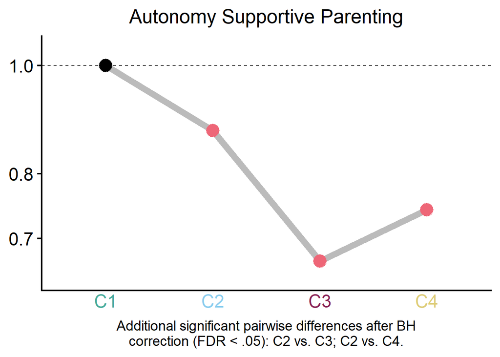

Figure 11

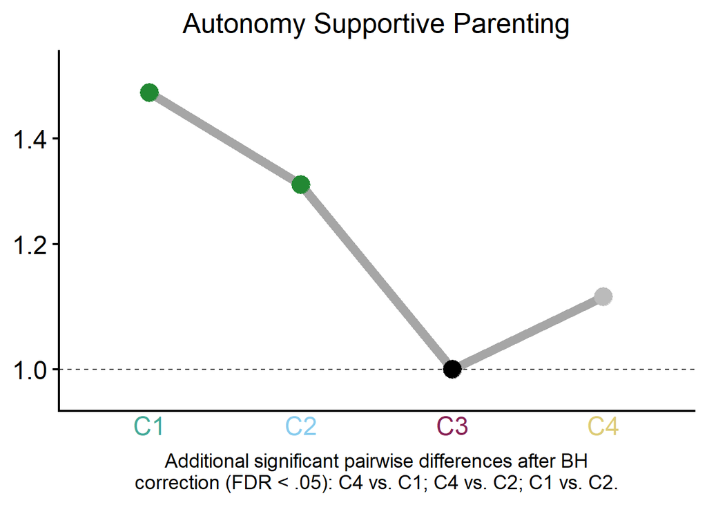

Figure 12

## Biological Sex

**C1 graph code**

```r
# ── Select Predictor and Significant Comparisons ──────────────────────────────────
pred_var   <- "female"
pred_data  <- c1_or_long %>% filter(predictor_var == pred_var)
pred_title <- pred_titles[pred_var]

# This predictor's name in the pairs sheet (differs from tidy_params() name for sex)
pairs_pred_name <- "bio_sexD"

# ── Identify Additional Pairwise Differences ──────────────────────────────────────
other_sig_c1 <- c1_pairs %>%
  filter(predictor == pairs_pred_name,
         cluster_a != 1, cluster_b != 1,
         sig == TRUE) %>%
  mutate(pair_label = paste0("C", cluster_a, " vs. C", cluster_b)) %>%
  pull(pair_label)

# Caption text summarizing those additional differences
fig_caption_c1 <- if (length(other_sig_c1) > 0) {
  paste0("Additional significant pairwise differences after BH correction (FDR < .05): ",
         paste(other_sig_c1, collapse = "; "), ".")
} else {
  "No additional pairwise differences were significant after BH correction."
}

# Build this predictor's panel
p_line_c1_female <- ggplot(pred_data, aes(x = cluster, y = OR)) +
  geom_hline(yintercept = 1.0,
             linetype   = or_refline_type,
             color      = or_refline_color,
             linewidth  = 0.4) +
  geom_line(aes(group = 1),
            color     = "#BBBBBB",
            linewidth = or_line_size,
            linetype  = "solid") +
  geom_point(aes(fill = sig_label, color = sig_label),
             shape  = or_point_shape,
             size   = or_point_size,
             stroke = 0.5) +
  scale_fill_manual(values = or_legend_colors, name = NULL, drop = FALSE) +
  scale_color_manual(values = or_legend_colors, name = NULL, drop = FALSE) +
  scale_y_log10(
    labels = label_number(accuracy = 0.1),
    expand = expansion(mult = c(0.15, 0.15))) +
  labs(title = pred_title,
       caption = str_wrap(fig_caption_c1, width = 60)) +
  theme_classic(base_size = axis_text_size, base_family = plot_font) +
  theme(
    legend.position    = "none",
    plot.caption    = element_text(size = 14, hjust = .5, face = "plain",
                                   family = plot_font),
    plot.title         = element_text(size = axis_title_size, face = "plain",
                                      hjust = 0.5, family = plot_font),
    axis.title.y       = element_blank(),
    axis.title.x       = element_blank(),
    axis.text.x        = element_text(size = axis_text_size, face = "plain",
                                      family = plot_font, angle = 0,
                                      hjust = .5, vjust = 1,
                                      color = x_axis_colors_c1),
    axis.text.y        = element_text(size = axis_text_size, family = plot_font,
                                      face = "plain"),
    axis.ticks.x       = element_blank(),
    panel.grid.major.y = element_blank(),
    panel.grid.major.x = element_blank(),
    plot.background    = element_rect(fill = NA, color = NA),
    panel.background   = element_rect(fill = NA, color = NA))
```

**C3 graph code**

```r
# ── Select Predictor and Significant Comparisons ──────────────────────────────────
pred_var   <- "female"
pred_data  <- c3_or_long %>% filter(predictor_var == pred_var)
pred_title <- pred_titles[pred_var]

# This predictor's name in the pairs sheet (differs from tidy_params() name for sex)
pairs_pred_name <- "bio_sexD"

# ── Identify Additional Pairwise Differences ──────────────────────────────────────
other_sig_c3 <- c3_pairs %>%
  filter(predictor == pairs_pred_name,
         cluster_a != 3, cluster_b != 3,
         sig == TRUE) %>%
  mutate(pair_label = paste0("C", cluster_a, " vs. C", cluster_b)) %>%
  pull(pair_label)

# Caption text summarizing those additional differences
fig_caption_c3 <- if (length(other_sig_c3) > 0) {
  paste0("Additional significant pairwise differences after BH correction (FDR < .05): ",
         paste(other_sig_c3, collapse = "; "), ".")
} else {
  "No additional pairwise differences were significant after BH correction."
}

# Build this predictor's panel
p_line_c3_female <- ggplot(pred_data, aes(x = cluster, y = OR)) +
  geom_hline(yintercept = 1.0,
             linetype   = or_refline_type,
             color      = or_refline_color,
             linewidth  = 0.4) +
  geom_line(aes(group = 1),
            color     = "grey65",
            linewidth = or_line_size,
            linetype  = "solid") +
  geom_point(aes(fill = sig_label, color = sig_label),
             shape  = or_point_shape,
             size   = or_point_size,
             stroke = 0.5) +
  scale_fill_manual(values = or_legend_colors, name = NULL, drop = FALSE) +
  scale_color_manual(values = or_legend_colors, name = NULL, drop = FALSE) +
  scale_y_log10(
    labels = label_number(accuracy = 0.1),
    expand = expansion(mult = c(0.15, 0.15))) +
  labs(title = pred_title,
       caption = str_wrap(fig_caption_c3, width = 60)) +
  theme_classic(base_size = axis_text_size, base_family = plot_font) +
  theme(
    legend.position    = "none",
    plot.caption    = element_text(size = 14, hjust = .5, face = "plain",
                                   family = plot_font),
    plot.title         = element_text(size = axis_title_size, face = "plain",
                                      hjust = 0.5, family = plot_font),
    axis.title.y       = element_blank(),
    axis.title.x       = element_blank(),
    axis.text.x        = element_text(size = axis_text_size, face = "plain",
                                      family = plot_font, angle = 0,
                                      hjust = .5, vjust = 1,
                                      color = x_axis_colors_c3),
    axis.text.y        = element_text(size = axis_text_size, family = plot_font,
                                      face = "plain"),
    axis.ticks.x       = element_blank(),
    panel.grid.major.y = element_blank(),
    panel.grid.major.x = element_blank(),
    plot.background    = element_rect(fill = NA, color = NA),
    panel.background   = element_rect(fill = NA, color = NA))
```

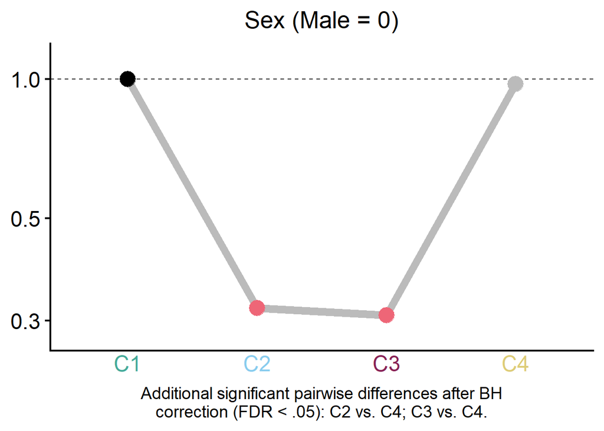

Figure 13

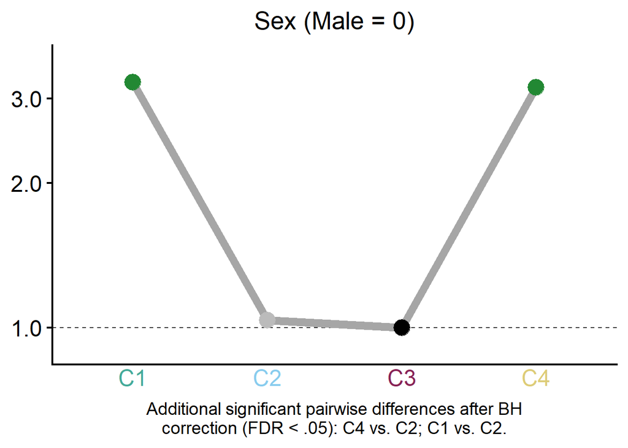

Figure 14

## Child Age

**C1 graph code**

```r
# ── Select Predictor and Significant Comparisons ──────────────────────────────────
pred_var   <- "Zwave1age"
pred_data  <- c1_or_long %>% filter(predictor_var == pred_var)
pred_title <- pred_titles[pred_var]

# This predictor's name in the pairs sheet
pairs_pred_name <- "Zwave1age"

# ── Identify Additional Pairwise Differences ──────────────────────────────────────
other_sig_c1 <- c1_pairs %>%
  filter(predictor == pairs_pred_name,
         cluster_a != 1, cluster_b != 1,
         sig == TRUE) %>%
  mutate(pair_label = paste0("C", cluster_a, " vs. C", cluster_b)) %>%
  pull(pair_label)

# Caption text summarizing those additional differences
fig_caption_c1 <- if (length(other_sig_c1) > 0) {
  paste0("Additional significant pairwise differences after BH correction (FDR < .05): ",
         paste(other_sig_c1, collapse = "; "), ".")
} else {
  "No additional pairwise differences were significant after BH correction."
}

# Build this predictor's panel
p_line_c1_age <- ggplot(pred_data, aes(x = cluster, y = OR)) +
  geom_hline(yintercept = 1.0,
             linetype   = or_refline_type,
             color      = or_refline_color,
             linewidth  = 0.4) +
  geom_line(aes(group = 1),
            color     = "#BBBBBB",
            linewidth = or_line_size,
            linetype  = "solid") +
  geom_point(aes(fill = sig_label, color = sig_label),
             shape  = or_point_shape,
             size   = or_point_size,
             stroke = 0.5) +
  scale_fill_manual(values = or_legend_colors, name = NULL, drop = FALSE) +
  scale_color_manual(values = or_legend_colors, name = NULL, drop = FALSE) +
  scale_y_log10(
    labels = label_number(accuracy = 0.1),
    expand = expansion(mult = c(0.15, 0.15))) +
  labs(title = pred_title,
       caption = str_wrap(fig_caption_c1, width = 60)) +
  theme_classic(base_size = axis_text_size, base_family = plot_font) +
  theme(
    legend.position    = "none",
    plot.caption    = element_text(size = 14, hjust = .5, face = "plain",
                                   family = plot_font),
    plot.title         = element_text(size = axis_title_size, face = "plain",
                                      hjust = 0.5, family = plot_font),
    axis.title.y       = element_blank(),
    axis.title.x       = element_blank(),
    axis.text.x        = element_text(size = axis_text_size, face = "plain",
                                      family = plot_font, angle = 0,
                                      hjust = .5, vjust = 1,
                                      color = x_axis_colors_c1),
    axis.text.y        = element_text(size = axis_text_size, family = plot_font,
                                      face = "plain"),
    axis.ticks.x       = element_blank(),
    panel.grid.major.y = element_blank(),
    panel.grid.major.x = element_blank(),
    plot.background    = element_rect(fill = NA, color = NA),
    panel.background   = element_rect(fill = NA, color = NA))
```

**C3 graph code**

```r
# ── Select Predictor and Significant Comparisons ──────────────────────────────────
pred_var   <- "Zwave1age"
pred_data  <- c3_or_long %>% filter(predictor_var == pred_var)
pred_title <- pred_titles[pred_var]

# This predictor's name in the pairs sheet
pairs_pred_name <- "Zwave1age"

# ── Identify Additional Pairwise Differences ──────────────────────────────────────
other_sig_c3 <- c3_pairs %>%
  filter(predictor == pairs_pred_name,
         cluster_a != 3, cluster_b != 3,
         sig == TRUE) %>%
  mutate(pair_label = paste0("C", cluster_a, " vs. C", cluster_b)) %>%
  pull(pair_label)

# Caption text summarizing those additional differences
fig_caption_c3 <- if (length(other_sig_c3) > 0) {
  paste0("Additional significant pairwise differences after BH correction (FDR < .05): ",
         paste(other_sig_c3, collapse = "; "), ".")
} else {
  "No additional pairwise differences were significant after BH correction."
}

# Build this predictor's panel
p_line_c3_age <- ggplot(pred_data, aes(x = cluster, y = OR)) +
  geom_hline(yintercept = 1.0,
             linetype   = or_refline_type,
             color      = or_refline_color,
             linewidth  = 0.4) +
  geom_line(aes(group = 1),
            color     = "grey65",
            linewidth = or_line_size,
            linetype  = "solid") +
  geom_point(aes(fill = sig_label, color = sig_label),
             shape  = or_point_shape,
             size   = or_point_size,
             stroke = 0.5) +
  scale_fill_manual(values = or_legend_colors, name = NULL, drop = FALSE) +
  scale_color_manual(values = or_legend_colors, name = NULL, drop = FALSE) +
  scale_y_log10(
    labels = label_number(accuracy = 0.1),
    expand = expansion(mult = c(0.15, 0.15))) +
  labs(title = pred_title,
       caption = str_wrap(fig_caption_c3, width = 60)) +
  theme_classic(base_size = axis_text_size, base_family = plot_font) +
  theme(
    legend.position    = "none",
    plot.caption    = element_text(size = 14, hjust = .5, face = "plain",
                                   family = plot_font),
    plot.title         = element_text(size = axis_title_size, face = "plain",
                                      hjust = 0.5, family = plot_font),
    axis.title.y       = element_blank(),
    axis.title.x       = element_blank(),
    axis.text.x        = element_text(size = axis_text_size, face = "plain",
                                      family = plot_font, angle = 0,
                                      hjust = .5, vjust = 1,
                                      color = x_axis_colors_c3),
    axis.text.y        = element_text(size = axis_text_size, family = plot_font,
                                      face = "plain"),
    axis.ticks.x       = element_blank(),
    panel.grid.major.y = element_blank(),
    panel.grid.major.x = element_blank(),
    plot.background    = element_rect(fill = NA, color = NA),
    panel.background   = element_rect(fill = NA, color = NA))
```

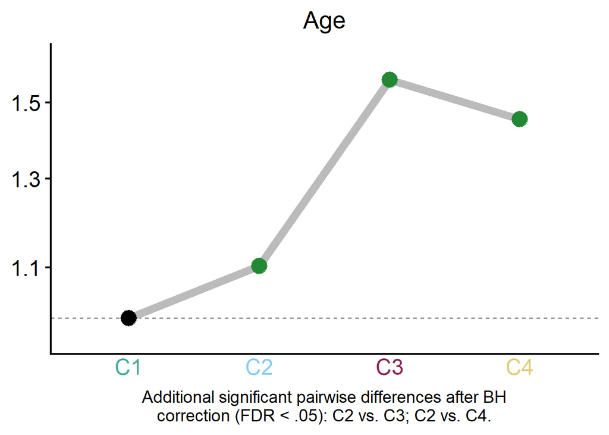

Figure 15

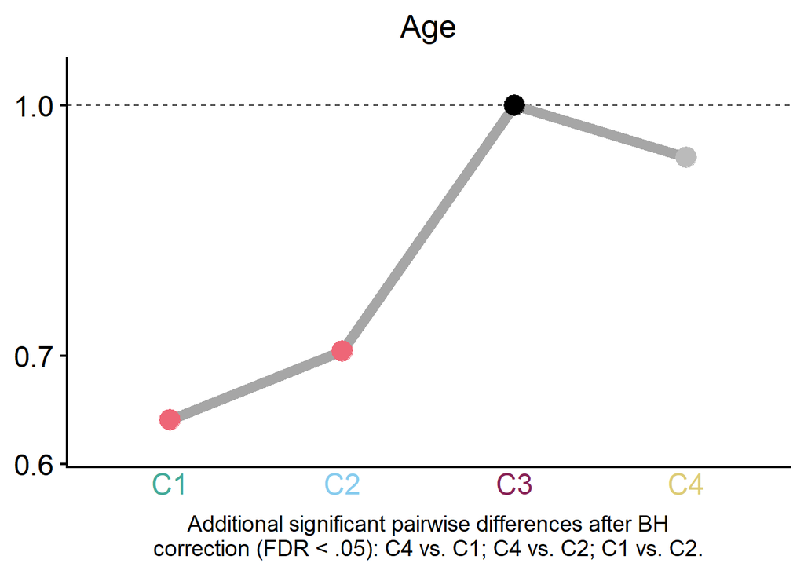

Figure 16

## Peer Substance Use

**C1 graph code**

```r
# ── Select Predictor and Significant Comparisons ──────────────────────────────────
pred_var   <- "Zpeer_subuse"
pred_data  <- c1_or_long %>% filter(predictor_var == pred_var)
pred_title <- pred_titles[pred_var]

# This predictor's name in the pairs sheet
pairs_pred_name <- "Zpeer_subuse"

# ── Identify Additional Pairwise Differences ──────────────────────────────────────
other_sig_c1 <- c1_pairs %>%
  filter(predictor == pairs_pred_name,
         cluster_a != 1, cluster_b != 1,
         sig == TRUE) %>%
  mutate(pair_label = paste0("C", cluster_a, " vs. C", cluster_b)) %>%
  pull(pair_label)

# Caption text summarizing those additional differences
fig_caption_c1 <- if (length(other_sig_c1) > 0) {
  paste0("Additional significant pairwise differences after BH correction (FDR < .05): ",
         paste(other_sig_c1, collapse = "; "), ".")
} else {
  "No additional pairwise differences were significant after BH correction."
}

# Build this predictor's panel
p_line_c1_peer <- ggplot(pred_data, aes(x = cluster, y = OR)) +
  geom_hline(yintercept = 1.0,
             linetype   = or_refline_type,
             color      = or_refline_color,
             linewidth  = 0.4) +
  geom_line(aes(group = 1),
            color     = "#BBBBBB",
            linewidth = or_line_size,
            linetype  = "solid") +
  geom_point(aes(fill = sig_label, color = sig_label),
             shape  = or_point_shape,
             size   = or_point_size,
             stroke = 0.5) +
  scale_fill_manual(values = or_legend_colors, name = NULL, drop = FALSE) +
  scale_color_manual(values = or_legend_colors, name = NULL, drop = FALSE) +
  scale_y_log10(
    labels = label_number(accuracy = 0.1),
    expand = expansion(mult = c(0.15, 0.15))) +
  labs(title = pred_title,
       caption = str_wrap(fig_caption_c1, width = 60)) +
  theme_classic(base_size = axis_text_size, base_family = plot_font) +
  theme(
    legend.position    = "none",
    plot.caption    = element_text(size = 14, hjust = .5, face = "plain",
                                   family = plot_font),
    plot.title         = element_text(size = axis_title_size, face = "plain",
                                      hjust = 0.5, family = plot_font),
    axis.title.y       = element_blank(),
    axis.title.x       = element_blank(),
    axis.text.x        = element_text(size = axis_text_size, face = "plain",
                                      family = plot_font, angle = 0,
                                      hjust = .5, vjust = 1,
                                      color = x_axis_colors_c1),
    axis.text.y        = element_text(size = axis_text_size, family = plot_font,
                                      face = "plain"),
    axis.ticks.x       = element_blank(),
    panel.grid.major.y = element_blank(),
    panel.grid.major.x = element_blank(),
    plot.background    = element_rect(fill = NA, color = NA),
    panel.background   = element_rect(fill = NA, color = NA))
```

**C3 graph code**

```r
# ── Select Predictor and Significant Comparisons ──────────────────────────────────
pred_var   <- "Zpeer_subuse"
pred_data  <- c3_or_long %>% filter(predictor_var == pred_var)
pred_title <- pred_titles[pred_var]

# This predictor's name in the pairs sheet
pairs_pred_name <- "Zpeer_subuse"

# ── Identify Additional Pairwise Differences ──────────────────────────────────────
other_sig_c3 <- c3_pairs %>%
  filter(predictor == pairs_pred_name,
         cluster_a != 3, cluster_b != 3,
         sig == TRUE) %>%
  mutate(pair_label = paste0("C", cluster_a, " vs. C", cluster_b)) %>%
  pull(pair_label)

# Caption text summarizing those additional differences
fig_caption_c3 <- if (length(other_sig_c3) > 0) {
  paste0("Additional significant pairwise differences after BH correction (FDR < .05): ",
         paste(other_sig_c3, collapse = "; "), ".")
} else {
  "No additional pairwise differences were significant after BH correction."
}

# Build this predictor's panel
p_line_c3_peer <- ggplot(pred_data, aes(x = cluster, y = OR)) +
  geom_hline(yintercept = 1.0,
             linetype   = or_refline_type,
             color      = or_refline_color,
             linewidth  = 0.4) +
  geom_line(aes(group = 1),
            color     = "grey65",
            linewidth = or_line_size,
            linetype  = "solid") +
  geom_point(aes(fill = sig_label, color = sig_label),
             shape  = or_point_shape,
             size   = or_point_size,
             stroke = 0.5) +
  scale_fill_manual(values = or_legend_colors, name = NULL, drop = FALSE) +
  scale_color_manual(values = or_legend_colors, name = NULL, drop = FALSE) +
  scale_y_log10(
    labels = label_number(accuracy = 0.1),
    expand = expansion(mult = c(0.15, 0.15))) +
  labs(title = pred_title,
       caption = str_wrap(fig_caption_c3, width = 60)) +
  theme_classic(base_size = axis_text_size, base_family = plot_font) +
  theme(
    legend.position    = "none",
    plot.caption    = element_text(size = 14, hjust = .5, face = "plain",
                                   family = plot_font),
    plot.title         = element_text(size = axis_title_size, face = "plain",
                                      hjust = 0.5, family = plot_font),
    axis.title.y       = element_blank(),
    axis.title.x       = element_blank(),
    axis.text.x        = element_text(size = axis_text_size, face = "plain",
                                      family = plot_font, angle = 0,
                                      hjust = .5, vjust = 1,
                                      color = x_axis_colors_c3),
    axis.text.y        = element_text(size = axis_text_size, family = plot_font,
                                      face = "plain"),
    axis.ticks.x       = element_blank(),
    panel.grid.major.y = element_blank(),
    panel.grid.major.x = element_blank(),
    plot.background    = element_rect(fill = NA, color = NA),
    panel.background   = element_rect(fill = NA, color = NA))
```

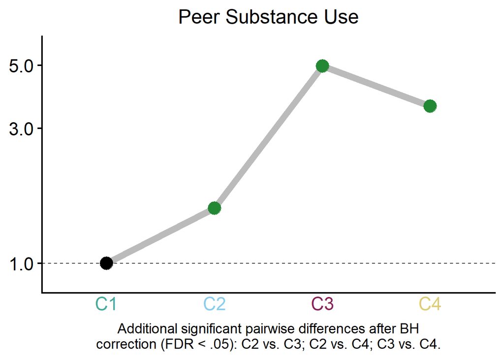

Figure 17

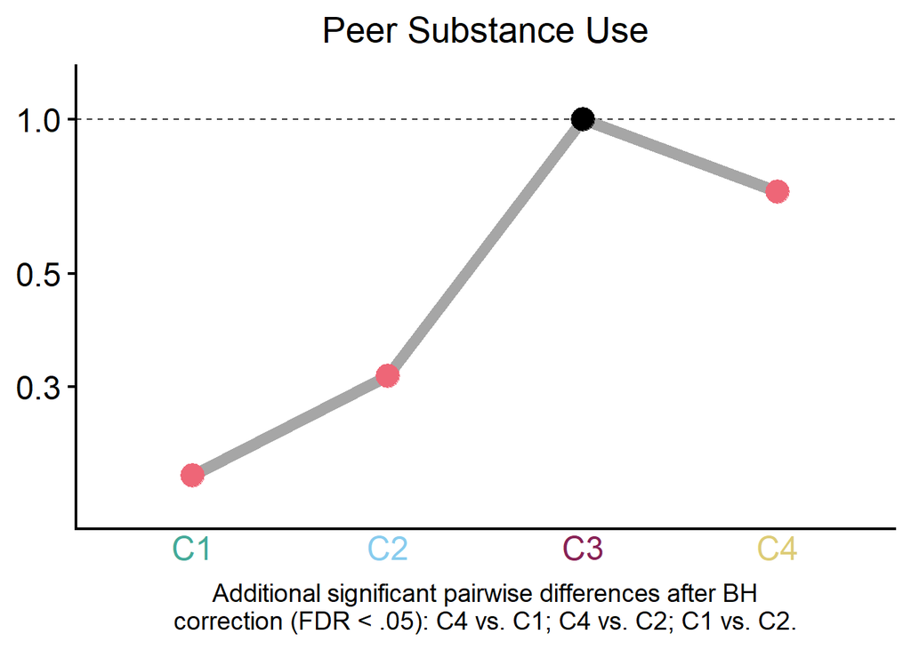

Figure 18

## Pubertal Timing

**C1 graph code**

```r
# ── Select Predictor and Significant Comparisons ──────────────────────────────────
pred_var   <- "pub_timing"
pred_data  <- c1_or_long %>% filter(predictor_var == pred_var)
pred_title <- pred_titles[pred_var]

# This predictor's name in the pairs sheet
pairs_pred_name <- "pub_timing"

# ── Identify Additional Pairwise Differences ──────────────────────────────────────
other_sig_c1 <- c1_pairs %>%
  filter(predictor == pairs_pred_name,
         cluster_a != 1, cluster_b != 1,
         sig == TRUE) %>%
  mutate(pair_label = paste0("C", cluster_a, " vs. C", cluster_b)) %>%
  pull(pair_label)

# Caption text summarizing those additional differences
fig_caption_c1 <- if (length(other_sig_c1) > 0) {
  paste0("Additional significant pairwise differences after BH correction (FDR < .05): ",
         paste(other_sig_c1, collapse = "; "), ".")
} else {
  "No additional pairwise differences were significant after BH correction."
}

# Build this predictor's panel
p_line_c1_pub <- ggplot(pred_data, aes(x = cluster, y = OR)) +
  geom_hline(yintercept = 1.0,
             linetype   = or_refline_type,
             color      = or_refline_color,
             linewidth  = 0.4) +
  geom_line(aes(group = 1),
            color     = "#BBBBBB",
            linewidth = or_line_size,
            linetype  = "solid") +
  geom_point(aes(fill = sig_label, color = sig_label),
             shape  = or_point_shape,
             size   = or_point_size,
             stroke = 0.5) +
  scale_fill_manual(values = or_legend_colors, name = NULL, drop = FALSE) +
  scale_color_manual(values = or_legend_colors, name = NULL, drop = FALSE) +
  scale_y_log10(
    labels = label_number(accuracy = 0.1),
    expand = expansion(mult = c(0.15, 0.15))) +
  labs(title = pred_title,
       caption = str_wrap(fig_caption_c1, width = 60)) +
  theme_classic(base_size = axis_text_size, base_family = plot_font) +
  theme(
    legend.position    = "none",
    plot.caption    = element_text(size = 14, hjust = .5, face = "plain",
                                   family = plot_font),
    plot.title         = element_text(size = axis_title_size, face = "plain",
                                      hjust = 0.5, family = plot_font),
    axis.title.y       = element_blank(),
    axis.title.x       = element_blank(),
    axis.text.x        = element_text(size = axis_text_size, face = "plain",
                                      family = plot_font, angle = 0,
                                      hjust = .5, vjust = 1,
                                      color = x_axis_colors_c1),
    axis.text.y        = element_text(size = axis_text_size, family = plot_font,
                                      face = "plain"),
    axis.ticks.x       = element_blank(),
    panel.grid.major.y = element_blank(),
    panel.grid.major.x = element_blank(),
    plot.background    = element_rect(fill = NA, color = NA),
    panel.background   = element_rect(fill = NA, color = NA))
```

**C3 graph code**

```r
# ── Select Predictor and Significant Comparisons ──────────────────────────────────
pred_var   <- "pub_timing"
pred_data  <- c3_or_long %>% filter(predictor_var == pred_var)
pred_title <- pred_titles[pred_var]

# This predictor's name in the pairs sheet
pairs_pred_name <- "pub_timing"

# ── Identify Additional Pairwise Differences ──────────────────────────────────────
other_sig_c3 <- c3_pairs %>%
  filter(predictor == pairs_pred_name,
         cluster_a != 3, cluster_b != 3,
         sig == TRUE) %>%
  mutate(pair_label = paste0("C", cluster_a, " vs. C", cluster_b)) %>%
  pull(pair_label)

# Caption text summarizing those additional differences
fig_caption_c3 <- if (length(other_sig_c3) > 0) {
  paste0("Additional significant pairwise differences after BH correction (FDR < .05): ",
         paste(other_sig_c3, collapse = "; "), ".")
} else {
  "No additional pairwise differences were significant after BH correction."
}

# Build this predictor's panel
p_line_c3_pub <- ggplot(pred_data, aes(x = cluster, y = OR)) +
  geom_hline(yintercept = 1.0,
             linetype   = or_refline_type,
             color      = or_refline_color,
             linewidth  = 0.4) +
  geom_line(aes(group = 1),
            color     = "grey65",
            linewidth = or_line_size,
            linetype  = "solid") +
  geom_point(aes(fill = sig_label, color = sig_label),
             shape  = or_point_shape,
             size   = or_point_size,
             stroke = 0.5) +
  scale_fill_manual(values = or_legend_colors, name = NULL, drop = FALSE) +
  scale_color_manual(values = or_legend_colors, name = NULL, drop = FALSE) +
  scale_y_log10(
    labels = label_number(accuracy = 0.1),
    expand = expansion(mult = c(0.15, 0.15))) +
  labs(title = pred_title,
       caption = str_wrap(fig_caption_c3, width = 60)) +
  theme_classic(base_size = axis_text_size, base_family = plot_font) +
  theme(
    legend.position    = "none",
    plot.caption    = element_text(size = 14, hjust = .5, face = "plain",
                                   family = plot_font),
    plot.title         = element_text(size = axis_title_size, face = "plain",
                                      hjust = 0.5, family = plot_font),
    axis.title.y       = element_blank(),
    axis.title.x       = element_blank(),
    axis.text.x        = element_text(size = axis_text_size, face = "plain",
                                      family = plot_font, angle = 0,
                                      hjust = .5, vjust = 1,
                                      color = x_axis_colors_c3),
    axis.text.y        = element_text(size = axis_text_size, family = plot_font,
                                      face = "plain"),
    axis.ticks.x       = element_blank(),
    panel.grid.major.y = element_blank(),
    panel.grid.major.x = element_blank(),
    plot.background    = element_rect(fill = NA, color = NA),
    panel.background   = element_rect(fill = NA, color = NA))
```

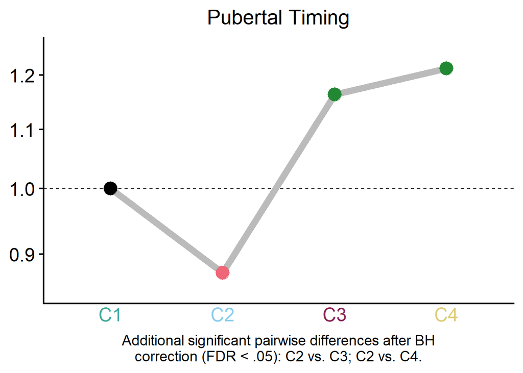

Figure 19

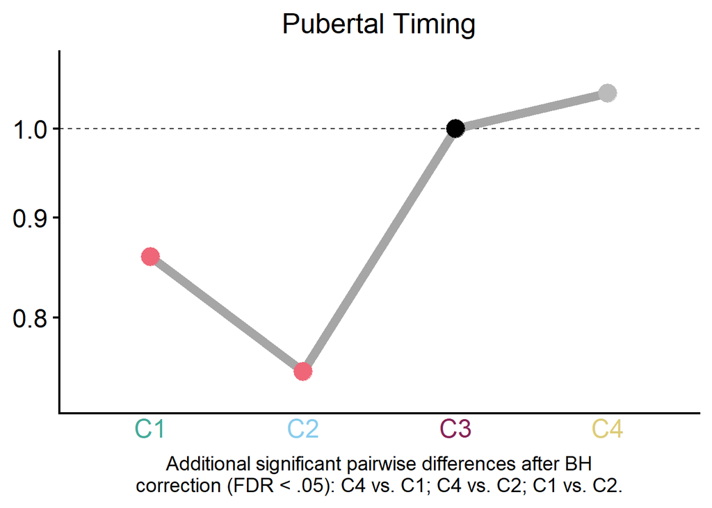

Figure 20

Back to top

## References

Benjamini, Yoav, and Yosef Hochberg. 1995. “Controlling the False Discovery Rate: A Practical and Powerful Approach to Multiple Testing.” *Journal of the Royal Statistical Society Series B: Statistical Methodology* 57 (1): 289–300. https://doi.org/10.1111/j.2517-6161.1995.tb02031.x.

———. 2000. “On the Adaptive Control of the False Discovery Rate in Multiple Testing with Independent Statistics.” *Journal of Educational and Behavioral Statistics* 25 (1): 60–83. https://doi.org/10.2307/1165312.

Bergman, Lars R., and David Magnusson. 1997. “A Person-Oriented Approach in Research on Developmental Psychopathology.” *Development and Psychopathology* 9 (2): 291–319. https://doi.org/10.1017/S095457949700206X.

Bolck, Annabel, Marcel Croon, and Jacques Hagenaars. 2004. “Estimating Latent Structure Models with Categorical Variables: One-Step Versus Three-Step Estimators.” *Political Analysis* 12 (1): 3–27. https://www.jstor.org.ezaccess.libraries.psu.edu/stable/25791751.

Deci, Edward L., and Richard M. Ryan. 2013. “The Importance of Autonomy for Development and Well-Being.” In, edited by Bryan W. Sokol, Frederick M. E. Grouzet, and Ulrich Müller, 1st ed., 19–46. Cambridge University Press. https://doi.org/10.1017/CBO9781139152198.005.

Dishion, Thomas J, Joan McCord, and Francois Poulin. 1999. “When Interventions Harm: Peer Groups and Problem Behavior.” *American Psychologist*, 10.

Dishion, Thomas J., and Jessica M. Tipsord. 2011. “Peer Contagion in Child and Adolescent Social and Emotional Development.” *Annual Review of Psychology* 62: 189–214. https://doi.org/10.1146/annurev.psych.093008.100412.

Duell, Natasha, Laurence Steinberg, Grace Icenogle, Jason Chein, Nandita Chaudhary, Laura Di Giunta, Kenneth A. Dodge, et al. 2018. “Age Patterns in Risk Taking Across the World.” *Journal of Youth and Adolescence* 47 (5): 1052–72. https://doi.org/10.1007/s10964-017-0752-y.

Henneberger, Angela K., Dawnsha R. Mushonga, and Alison M. Preston. 2021. “Peer Influence and Adolescent Substance Use: A Systematic Review of Dynamic Social Network Research.” *Adolescent Research Review* 6 (1): 57–73. https://doi.org/10.1007/s40894-019-00130-0.

Miller, Shari, Patrick S. Malone, and Kenneth A. Dodge. 2010. “Developmental Trajectories of Boys’ and Girls’ Delinquency: Sex Differences and Links to Later Adolescent Outcomes.” *Journal of Abnormal Child Psychology* 38 (7): 1021–32. https://doi.org/10.1007/s10802-010-9430-1.

Moffitt, Terrie E. 2017. “Adolescence-Limited and Life-Course-Persistent Antisocial Behavior: A Developmental Taxonomy.” *Biosocial Theories of Crime*, 6996.

Natsuaki, Misaki N., Michael C. Biehl, and Xiaojia Ge. 2009. “Trajectories of Depressed Mood From Early Adolescence to Young Adulthood: The Effects of Pubertal Timing and Adolescent Dating.” *Journal of Research on Adolescence* 19 (1): 47–74. https://doi.org/10.1111/j.1532-7795.2009.00581.x.

Ryan, Richard M., and Edward L. Deci. 2022. “Self-Determination Theory.” In, edited by Filomena Maggino, 1–7. Cham: Springer International Publishing. https://doi.org/10.1007/978-3-319-69909-7_2630-2.